# Inteligência Artificial como Instrumento de Medição

Minicurso completo em slides · trilha Python

Prof. Dr. Jodavid Ferreira · Departamento de Estatística · UFPE

II DataPOL · 24 a 26 de novembro de 2026 · CCEN/UFPE

“O futuro traz novas perguntas.  
Os dados ampliam nossas formas de responder.”

…mas **quem mede a régua?**

## Duas perguntas para hoje

### Substantiva

Quando o Congresso legisla sobre **IA**, ele quer **punir**, **regular** ou **promover**?

E isso varia entre campos políticos?

### Metodológica

Se usarmos um **LLM** para responder, **como sabemos se a resposta está certa**?

E como **reproduzir** a resposta daqui a dois anos?

> Na I edição do DataPOL vocês viram como **usar** IA para analisar textos. Hoje vamos **medir** com ela e medir o erro dela, **linha a linha de código**.

## Por que agora?

- **Eleições de 2026**: primeiras eleições gerais sob a Res. TSE nº 23.755/2026 (rotulagem obrigatória, deepfakes proibidos, IA não pode recomendar voto)
- **Marco Legal da IA (PL 2338/2023)**: aprovado no Senado em dez/2024, **aguardando parecer** na Câmara
- **304 projetos de lei** sobre IA no Congresso, 120 só em 2026
- LLMs viraram infraestrutura de pesquisa, mas são **instáveis, sensíveis ao prompt e enviesados**

## A “fase atual” da estatística

- **Breiman (2001)**: duas culturas, *modelar* × *prever*

*Modelar* = explicar como os dados são gerados e medir a incerteza (a estatística clássica). *Prever* = acertar a resposta, mesmo sem entender o mecanismo (o aprendizado de máquina).

- **2018–2026**: a síntese, com ML **a serviço da inferência**

As previsões do ML viram matéria-prima para estimar efeitos e proporções **com intervalo de confiança válido** (quatro exemplos no próximo slide).

**O fio comum**

Previsões de modelos podem tornar a inferência **mais precisa**, desde que o erro delas seja **medido e corrigido**, e não ignorado.

**Traduzindo para hoje:** o LLM rotula todas as ementas (barato, mas com erro) → a amostra-ouro mede esse erro → o PPI corrige a estimativa e alarga o IC na medida certa. Usar os rótulos do LLM como se fossem a verdade é **ignorar** o erro.

## A síntese em quatro exemplos

| Método | O que faz, em uma frase |
| --- | --- |
| *Double ML* (Chernozhukov et al., 2018) | Usa ML para “limpar” a influência de muitas variáveis de controle e estima um **efeito causal** com IC válido |
| Predição conformal (Vovk et al., 2005) | Transforma a previsão de qualquer modelo num **intervalo** (ou num conjunto de rótulos possíveis) que contém a resposta certa com a frequência prometida, p. ex. 95% |
| *Prediction-Powered Inference* (Angelopoulos et al., *Science*, 2023) | Junta **muitas previsões** e **poucos rótulos verdadeiros**: mede o viés das previsões nos rotulados e o desconta. **É o que usamos no bloco 6** |
| *Design-based Supervised Learning* (Egami et al., 2023) | A mesma correção para **regressões** com rótulos de LLM, usando uma amostra codificada por especialistas e sorteada com probabilidades conhecidas |

Não é preciso dominar os quatro: hoje usamos só o **PPI** (e sua versão PPI++). Os outros mostram que a ideia é geral.

## Um LLM é um instrumento de medição

| Propriedade | Pergunta | Como medimos hoje |
| --- | --- | --- |
| **Validade** | Mede o que diz medir? | kappa contra a amostra-ouro, com IC bootstrap |
| **Onde erra** | Que erros comete? | matriz de confusão |
| **Viés** | Erra igual para todos os grupos? | acurácia por campo político |
| **Confiabilidade** | Mede sempre igual? | alfa de Krippendorff entre sementes e prompts |
| **Uso na inferência** | Como usar sem esconder o erro? | *Prediction-Powered Inference* |

## O caminho de hoje

```
%%{init: {"theme": "base", "themeVariables": {"lineColor": "#8f8d88", "primaryColor": "#eef4fc", "primaryBorderColor": "#7ba4de", "primaryTextColor": "#0b0b0b", "fontFamily": "Source Sans Pro, Helvetica Neue, Arial, sans-serif"}}}%%
flowchart LR
  A[APIs<br>Câmara + Senado] --> B[Corpus<br>304 ementas]
  B --> C[Livro de códigos<br>+ amostra-ouro]
  C --> D[Baselines<br>dicionário · TF-IDF]
  B --> E[LLM local<br>3 prompts · cache]
  C --> F[Validação<br>kappa · viés · reteste]
  D --> F
  E --> F
  F --> G[Inferência<br>PPI]
  G --> H[Reprodutibilidade]
  classDef foco fill:#1c3f6e,stroke:#1c3f6e,color:#ffffff
  class E foco
```

## Como este deck funciona

- Todo código com fundo cinza **foi executado** ao compilar os slides; o que aparece abaixo dele, em branco, é a **saída real**
- Chamadas que dependem de **internet** (APIs) ou do **Ollama** aparecem com o código, mas a saída vem dos **arquivos congelados** do material (`dados/bruto/`, `dados/cache_llm/`)
- As funções usadas estão em `python/medicao.py` e `python/anotar_llm.py`; mostramos o código delas nos slides
- O mesmo conteúdo existe em **R** (`slides/completo_R.qmd`) e em notebooks para o **Colab** (`python/01…05_*.ipynb`)

**Dica**

Para acompanhar: abra os notebooks no Colab ou rode as células deste deck na ordem, a partir da raiz do material.

## Organização do material

```
minicurso_IA_medicao/
├── python/
│   ├── medicao.py           ← coleta, métricas, PPI (espelho de R/funcoes_*.R)
│   ├── anotar_llm.py        ← anotação com cache e versionamento (gerou os dados)
│   └── 01_coleta … 05_inferencia.ipynb
├── R/                       ← trilha equivalente em R + _targets.R
├── prompts/                 ← prompt_v1, v2, v3 + CHANGELOG
├── modelos/                 ← Modelfile do s5-nano-instruct (Ollama)
├── dados/
│   ├── bruto/               ← respostas das APIs (congeladas)
│   ├── processado/          ← corpus.csv (304 proposições)
│   ├── anotacoes/           ← referência, amostra-ouro, baselines
│   ├── cache_llm/           ← TODAS as respostas do LLM
│   └── repeticao/           ← repetição a t = 0 (reprodutibilidade)
├── resultados/python/       ← tabelas e figuras geradas pelos notebooks
└── CODEBOOK.md · CHECKLIST.md · requirements.txt
```

## Preparar o ambiente

### No computador

```bash
# Python 3.11 (testado)
pip install -r requirements.txt
jupyter lab python/
```

### Para anotar com o LLM (opcional)

```bash
# https://ollama.com
ollama pull hf.co/maritaca-ai/S5-nano-GGUF:Q4_K_M
ollama create s5-nano-instruct \
  -f modelos/Modelfile.s5-nano-instruct
```

### No Google Colab

- Abra `python/01_coleta.ipynb` no Colab
- A **primeira célula** clona o repositório e ajusta o diretório
- Para o LLM: *Ambiente de execução → T4 GPU*; a célula de instalação do Ollama está no notebook 03

**Nota**

Não é preciso GPU nem chave de API: tudo roda a partir dos dados e do cache congelados.

## Configuração: a primeira célula

```python
import os, sys
from pathlib import Path

RAIZ = Path.cwd()                     # raiz do material (no Colab: a pasta clonada)
sys.path.insert(0, str(RAIZ / "python"))

import numpy as np
import pandas as pd
import matplotlib.pyplot as plt
from medicao import *                 # funções do minicurso
estilo_graficos()                     # tema comum às figuras

print("Raiz:", RAIZ.name)
print("Categorias:", CATEGORIAS)
print("Instrumento:", INSTRUMENTO)
```

```
Raiz: minicurso_IA_medicao_publico
Categorias: ['PUNIR', 'REGULAR', 'PROMOVER', 'OUTRO']
Instrumento: s5-nano-instruct
```

## O que há em `medicao.py`?

```python
import medicao, inspect
funcoes = [n for n, f in inspect.getmembers(medicao, inspect.isfunction)
           if f.__module__ == "medicao" and not n.startswith("_")]
for i in range(0, len(funcoes), 4):
    print("  ".join(f"{f:<24}" for f in funcoes[i:i + 4]))
```

```
alfa_krippendorff         boot_ic                   camara_autor              camara_partido_na_data
camara_proposicoes        camara_situacao           campo_politico            carrega_corpus
carrega_llm               carrega_ouro              classifica_dicionario     compara_estimadores
eleitoral_dicionario      est_humano                est_ingenuo               est_ppi
est_ppi_plus              estilo_graficos           extrai_partido_senado     f1_macro
ic_normal                 kappa_cohen               limpa_ementa              req_json
resumo_metricas           rotulo_run                senado_processos
```

- **Coleta:** `req_json`, `camara_*`, `senado_processos`, `limpa_ementa`, `campo_politico`
- **Medição:** `classifica_dicionario`, `kappa_cohen`, `alfa_krippendorff`, `f1_macro`, `boot_ic`
- **Inferência:** `est_humano`, `est_ingenuo`, `est_ppi`, `est_ppi_plus`, `compara_estimadores`

# 1 · Dados legislativos

`python/01_coleta.ipynb`

## O que vamos executar neste bloco

1. Entender a **anatomia** de uma requisição às APIs da Câmara e do Senado
2. Ler as funções de coleta: **retry**, **paginação**, **autor**, **partido na data**
3. Ver, com dados reais congelados, **o que as APIs devolveram**
4. **Reconstruir o corpus** a partir dos dados brutos, sem internet
5. Atribuir o **campo político** e descrever o corpus
6. Comparar duas coletas e ver que **a fonte muda**

**Nota**

A coleta completa faz centenas de chamadas (5 a 10 min). Em sala, partimos de `dados/bruto/`.

## APIs de dados abertos

### Câmara dos Deputados

`https://dadosabertos.camara.leg.br/api/v2`

- `/proposicoes?keywords=...&ano=...`
- `/proposicoes/{id}/autores`
- `/proposicoes/{id}` (situação)
- `/deputados/{id}/historico`

### Senado Federal

`https://legis.senado.leg.br/dadosabertos`

- `/processo?sigla=PL&termo=...`
- autoria já vem como texto: “Senador Fulano (PSD/MG)”

**Termos:** *inteligência artificial*, *deepfake*, *deep fake*, *conteúdo sintético* · **Anos:** 2019–2026 · **Tipo:** PL

## Anatomia de uma requisição

Montamos a URL **sem** enviar nada pela rede:

```python
import requests
URL_CAMARA = "https://dadosabertos.camara.leg.br/api/v2"
params = dict(keywords="deepfake", ano=2024, siglaTipo="PL", itens=100,
              pagina=1, ordem="ASC", ordenarPor="id")
req = requests.Request("GET", f"{URL_CAMARA}/proposicoes", params=params).prepare()
print(req.url)
```

```
https://dadosabertos.camara.leg.br/api/v2/proposicoes?keywords=deepfake&ano=2024&siglaTipo=PL&itens=100&pagina=1&ordem=ASC&ordenarPor=id
```

- `keywords`: busca textual feita por um **indexador da Câmara** (que não controlamos)
- `ano`: a API limita filtros de **data** a 3 meses; `ano` não tem esse limite
- `itens=100` + `pagina`: no máximo 100 resultados por página

## `req_json`: boas práticas com APIs públicas

```python
SESSAO = requests.Session()
SESSAO.headers.update({"Accept": "application/json",
                       "User-Agent": "Minicurso DataPOL/UFPE (fins acadêmicos)"})

def req_json(url, params=None, tentativas=4):
    """Requisição com retry e pausa (no máximo ~5 requisições/segundo)."""
    for t in range(tentativas):
        try:
            time.sleep(0.2)
            r = SESSAO.get(url, params=params, timeout=60)
            r.raise_for_status()
            return r.json()
        except requests.RequestException:
            if t == tentativas - 1:
                raise
            time.sleep(2 ** (t + 1))
```

- **Identifica** o cliente (`User-Agent`) · **limita a taxa** (0,2 s entre chamadas)
- **Tenta de novo** com espera exponencial (2, 4, 8 s): a Câmara devolveu erro 504 no meio da recoleta

## Uma chamada à Câmara

```python
res = req_json(f"{URL_CAMARA}/proposicoes", params)   # precisa de internet
res["dados"][0]
```

```
{'id': 2427155, 'uri': 'https://dadosabertos.camara.leg.br/api/v2/proposicoes/2427155',
 'siglaTipo': 'PL', 'codTipo': 139, 'numero': 3821, 'ano': 2024,
 'ementa': 'Altera o Decreto-Lei nº 2.848, de 7 de dezembro de 1940 (Código Penal), ...',
 'dataApresentacao': '2024-10-02T16:32'}
```

O material guarda o que a API devolveu em `dados/bruto/camara_raw.csv`:

```python
camara = pd.read_csv("dados/bruto/camara_raw.csv")
print(camara.shape)
camara[["id", "sigla", "numero", "ano", "data_apresentacao"]].head(3)
```

```
(265, 14)
```

|  | id | sigla | numero | ano | data_apresentacao |
| --- | --- | --- | --- | --- | --- |
| 0 | 2236340 | PL | 21 | 2020 | 2020-02-04T11:57 |
| 1 | 2236943 | PL | 240 | 2020 | 2020-02-11T17:23 |
| 2 | 2284814 | PL | 1969 | 2021 | 2021-05-26T16:54 |

## Paginação: `camara_proposicoes`

```python
def camara_proposicoes(termo, ano, tipos=("PL",)):
    """A API limita intervalos de datas a 3 meses; filtrar por `ano` evita isso."""
    saida, pagina = [], 1
    while True:
        res = req_json(f"{URL_CAMARA}/proposicoes",
                       dict(keywords=termo, ano=ano, siglaTipo=",".join(tipos), itens=100,
                            pagina=pagina, ordem="ASC", ordenarPor="id"))
        saida += res["dados"]
        if len(res["dados"]) < 100:      # última página
            break
        pagina += 1
    return pd.DataFrame([dict(id=x["id"], sigla=x["siglaTipo"], numero=x["numero"], ano=x["ano"],
                              ementa=x["ementa"], data_apresentacao=x["dataApresentacao"])
                         for x in saida])
```

No notebook, o laço é: `for t in TERMOS for a in ANOS` → 4 termos × 8 anos = **32 buscas**, depois `drop_duplicates("id")`.

## Quem é o autor? `camara_autor`

```python
def camara_autor(id_):
    """Primeiro autor (proponente) de uma proposição da Câmara."""
    res = req_json(f"{URL_CAMARA}/proposicoes/{id_}/autores")["dados"]
    if not res:
        return dict(id=id_)
    a = min(res, key=lambda x: x.get("ordemAssinatura") or 99)
    return dict(id=id_, autor=a["nome"], tipo_autor=a["tipo"], uri_autor=a.get("uri"),
                n_autores=len(res))
```

```python
camara[["autor", "tipo_autor", "n_autores", "uri_autor"]].head(3)
```

|  | autor | tipo_autor | n_autores | uri_autor |
| --- | --- | --- | --- | --- |
| 0 | Eduardo Bismarck | Deputado(a) | 1 | https://dadosabertos.camara.leg.br/api/v2/deputados/204541 |
| 1 | Léo Moraes | Deputado(a) | 1 | https://dadosabertos.camara.leg.br/api/v2/deputados/204359 |
| 2 | Gustavo Fruet | Deputado(a) | 1 | https://dadosabertos.camara.leg.br/api/v2/deputados/73460 |

- Uma chamada **por proposição**: é aqui que a coleta fica lenta
- A `uri_autor` leva ao **histórico** do deputado (próximo slide)

## Partido na data: o problema

Queremos o partido do autor **quando ele apresentou o projeto**, não o partido atual.

- O histórico do deputado (`/deputados/{id}/historico`) lista filiações com datas
- **Mas:** a API inclui registros “Partido no início da legislatura” **datados de 2023-02-01** para **todas** as legislaturas anteriores, com `situacao` vazia
- Resultado ingênuo: um deputado do **PL em 2023** aparecia como **PMDB** ou **PFL**
- Correção: descartar registros sem `situacao` e pegar o **último antes da data**

## Partido na data: o código

```python
def camara_partido_na_data(uri_deputado, data_ref):
    """Partido do deputado NA DATA da apresentação (não o partido atual!)."""
    vazio = dict(partido=None, uf=None)
    if not isinstance(uri_deputado, str) or "/deputados/" not in uri_deputado:
        return vazio
    h = req_json(f"{uri_deputado}/historico")["dados"]
    # Atenção: a API inclui registros "Nome/Partido no início da legislatura" com a
    # data de 2023-02-01 para TODAS as legislaturas anteriores (situacao = None).
    h = sorted([dict(dia=(x.get("dataHora") or "")[:10], partido=x.get("siglaPartido"),
                     uf=x.get("siglaUf"))
                for x in h if x.get("siglaPartido") and x.get("dataHora") and x.get("situacao")],
               key=lambda x: x["dia"])
    if not h:
        return vazio
    antes = [x for x in h if x["dia"] <= str(data_ref)[:10]]
    linha = antes[-1] if antes else h[0]
    return dict(partido=linha["partido"], uf=linha["uf"])
```

## Partido na data: demonstração sem internet

Um histórico **fictício**, no formato da API, com a armadilha:

```python
import medicao
historico = {"dados": [
    {"dataHora": "2019-02-01T00:00", "siglaPartido": "PSL", "siglaUf": "SP", "situacao": "Exercício"},
    {"dataHora": "2022-03-30T00:00", "siglaPartido": "PL",  "siglaUf": "SP", "situacao": "Exercício"},
    {"dataHora": "2023-02-01T00:00", "siglaPartido": "PMDB", "siglaUf": "SP", "situacao": None},
]}
original, medicao.req_json = medicao.req_json, lambda url, params=None: historico  # simula a API

ingenuo = max((x for x in historico["dados"] if x["dataHora"][:10] <= "2023-05-10"),
              key=lambda x: x["dataHora"])
print("Sem o filtro:", ingenuo["siglaPartido"])
print("Com o filtro:", camara_partido_na_data("https://.../deputados/1", "2023-05-10"))
medicao.req_json = original                                                        # restaura
```

```
Sem o filtro: PMDB
Com o filtro: {'partido': 'PL', 'uf': 'SP'}
```

## Senado: a autoria já traz o partido

```python
senado = pd.read_csv("dados/bruto/senado_raw.csv")
print(senado.shape)
senado[["identificacao", "data_apresentacao", "autoria"]].head(5)
```

```
(44, 7)
```

|  | identificacao | data_apresentacao | autoria |
| --- | --- | --- | --- |
| 0 | PL 5051/2019 | 2019-09-16 | Senador Styvenson Valentim (PODEMOS/RN) |
| 1 | PL 5691/2019 | 2019-10-24 | Senador Styvenson Valentim (PODEMOS/RN) |
| 2 | PL 872/2021 | 2021-03-12 | Senador Veneziano Vital do Rêgo (MDB/PB) |
| 3 | PL 21/2020 | 2021-09-30 | Câmara dos Deputados |
| 4 | PL 745/2022 | 2022-03-29 | Senador Jorge Kajuru (PODEMOS/GO) |

No Senado o partido **na data** já vem no texto da autoria. Basta extraí-lo com uma expressão regular.

## `extrai_partido_senado` em ação

```python
def extrai_partido_senado(autoria):
    m = re.search(r"\(([A-Za-zÀ-ú ]+)/([A-Z]{2})\)", autoria or "")
    return (m.group(1), m.group(2)) if m else (None, None)
```

```python
exemplos = ["Senador Rodrigo Pacheco (PSD/MG)",
            "Senadora Damares Alves (REPUBLICANOS/DF)",
            "Comissão de Comunicação e Direito Digital",
            None]
for a in exemplos:
    print(f"{str(a):<45} → {extrai_partido_senado(a)}")
```

```
Senador Rodrigo Pacheco (PSD/MG)              → ('PSD', 'MG')
Senadora Damares Alves (REPUBLICANOS/DF)      → ('REPUBLICANOS', 'DF')
Comissão de Comunicação e Direito Digital     → (None, None)
None                                          → (None, None)
```

- Autorias **coletivas** (comissões, Poder Executivo) ficam **sem partido** → campo “Sem partido/Outro”

## Limpeza mínima: `limpa_ementa`

```python
def limpa_ementa(x):
    x = re.sub(r"[\r\n]+", " ", x)
    x = re.sub(r"(?i)\s*NOVA EMENTA:.*$", "", x)    # mantém a ementa original
    return re.sub(r"\s+", " ", x).strip()
```

```python
bruta = camara.loc[0, "ementa"]
print("BRUTA:\n", bruta, "\n")
print("LIMPA:\n", limpa_ementa(bruta))
```

```
BRUTA:
 Estabelece princípios, direitos e deveres para o uso de inteligência artificial no Brasil, e dá outras providências.  NOVA EMENTA: Estabelece fundamentos, princípios e diretrizes para o desenvolvimento e a aplicação da inteligência artificial no Brasil; e dá outras providências.

LIMPA:
 Estabelece princípios, direitos e deveres para o uso de inteligência artificial no Brasil, e dá outras providências.
```

**Aviso**

Decisão de medição: ficamos com a ementa **original**, não com a reescrita. Outra escolha daria outro corpus.

## Montando o corpus: Câmara

```python
camara_pad = pd.DataFrame(dict(
    casa="Câmara",
    identificacao=camara["sigla"] + " " + camara["numero"].astype(str) + "/" + camara["ano"].astype(str),
    ano=camara["ano"], data_apresentacao=camara["data_apresentacao"].str[:10],
    ementa=camara["ementa"], autor=camara["autor"], tipo_autor=camara["tipo_autor"],
    partido=camara["partido"], uf=camara["uf"], situacao=camara["situacao"]))
camara_pad[["identificacao", "data_apresentacao", "partido", "uf"]].head(4)
```

|  | identificacao | data_apresentacao | partido | uf |
| --- | --- | --- | --- | --- |
| 0 | PL 21/2020 | 2020-02-04 | PDT | CE |
| 1 | PL 240/2020 | 2020-02-11 | PODE | RO |
| 2 | PL 1969/2021 | 2021-05-26 | PDT | PR |
| 3 | PL 705/2022 | 2022-03-24 | UNIÃO | RJ |

## Montando o corpus: Senado

```python
ps = senado["autoria"].apply(extrai_partido_senado)
senado_pad = pd.DataFrame(dict(
    casa="Senado", identificacao=senado["identificacao"],
    ano=senado["data_apresentacao"].str[:4].astype(int),
    data_apresentacao=senado["data_apresentacao"], ementa=senado["ementa"],
    autor=senado["autoria"].str.replace(r"\s*\(.*\)$", "", regex=True),
    tipo_autor=senado["autoria"].fillna("").str.startswith("Senador")
                                .map({True: "Senador(a)", False: "Outro"}),
    partido=[p for p, _ in ps], uf=[u for _, u in ps], situacao=senado["situacao"]))
senado_pad[["identificacao", "autor", "partido", "uf"]].head(4)
```

|  | identificacao | autor | partido | uf |
| --- | --- | --- | --- | --- |
| 0 | PL 5051/2019 | Senador Styvenson Valentim | PODEMOS | RN |
| 1 | PL 5691/2019 | Senador Styvenson Valentim | PODEMOS | RN |
| 2 | PL 872/2021 | Senador Veneziano Vital do Rêgo | MDB | PB |
| 3 | PL 21/2020 | Câmara dos Deputados | None | None |

## Unir, deduplicar, ordenar

```python
ANOS = list(range(2019, 2027))
# Senado primeiro: um PL do Senado remetido à Câmara aparece nas duas casas,
# e mantemos o registro da casa de origem (que traz o partido na data)
novo = (pd.concat([senado_pad, camara_pad], ignore_index=True)
        .drop_duplicates("identificacao")
        .assign(ementa=lambda d: d["ementa"].map(limpa_ementa),
                partido=lambda d: d["partido"].str.strip().str.upper()))
novo = novo[novo["ano"].isin(ANOS) & (novo["ementa"].str.len() > 20)]
novo = novo.sort_values("data_apresentacao", kind="stable").reset_index(drop=True)
novo.insert(0, "doc_id", [f"doc{i:04d}" for i in range(1, len(novo) + 1)])
print(len(camara_pad), "+", len(senado_pad), "registros →", len(novo), "proposições")
```

```
265 + 44 registros → 304 proposições
```

## Duplicatas: o mesmo PL nas duas casas

```python
dup = set(senado_pad["identificacao"]) & set(camara_pad["identificacao"])
print(sorted(dup))
camara_pad.loc[camara_pad["identificacao"] == "PL 2338/2023",
               ["casa", "identificacao", "autor", "partido"]]
```

```
['PL 21/2020', 'PL 2338/2023', 'PL 370/2024', 'PL 3821/2024', 'PL 750/2026']
```

|  | casa | identificacao | autor | partido |
| --- | --- | --- | --- | --- |
| 39 | Câmara | PL 2338/2023 | Senado Federal - Rodrigo Pacheco | NaN |

- Na Câmara, o autor do PL 2338/2023 é “Senado Federal”, **sem partido**
- No Senado, é o senador Rodrigo Pacheco (PSD/MG): por isso o Senado vem primeiro

## Campo político

```python
# Simplificação didática de Bolognesi, Ribeiro & Codato (2023), Dados 66(2)
ESQUERDA = {"PSOL", "PT", "PCDOB", "PDT", "PSB", "REDE", "PV"}
CENTRO   = {"MDB", "PSDB", "CIDADANIA", "PSD", "SOLIDARIEDADE", "AVANTE", "PMB"}
DIREITA  = {"PL", "PP", "UNIÃO", "REPUBLICANOS", "NOVO", "PSC", "PTB", "PODE", "PODEMOS",
            "PATRIOTA", "PRD", "DEM", "PSL", "PROS", "PRTB", "AGIR", "DC", "PMN", "MOBILIZA"}
```

```python
novo["campo"] = novo["partido"].map(campo_politico)
novo["ano_eleitoral"] = novo["ano"] % 2 == 0          # 2020, 2022, 2024, 2026
novo["campo"].value_counts()
```

```
campo
Direita              155
Esquerda              80
Centro                61
Sem partido/Outro      8
Name: count, dtype: int64
```

**Aviso**

O **campo** é ele próprio uma **medida**: depende de uma classificação de partidos, que mudam ao longo do tempo.

## O corpus reconstruído é o mesmo?

Comparamos o que acabamos de montar com `dados/processado/corpus.csv`:

```python
corpus = carrega_corpus(".")
m = novo.merge(corpus, on="identificacao", suffixes=("", "_oficial"))
for col in ["doc_id", "ementa", "partido", "campo"]:
    iguais = (m[col].fillna("") == m[col + "_oficial"].fillna("")).mean()
    print(f"{col:<8} idênticos em {iguais:.0%} das {len(m)} proposições")
```

```
doc_id   idênticos em 100% das 304 proposições
ementa   idênticos em 100% das 304 proposições
partido  idênticos em 100% das 304 proposições
campo    idênticos em 100% das 304 proposições
```

**Dica**

A partir dos dados brutos **congelados**, qualquer pessoa reconstrói o corpus, sem internet. É isso que torna a coleta auditável.

## O corpus final

```python
print(corpus.shape)
corpus[["doc_id", "casa", "identificacao", "partido", "campo", "ementa"]].head(6)
```

```
(304, 14)
```

|  | doc_id | casa | identificacao | partido | campo | ementa |
| --- | --- | --- | --- | --- | --- | --- |
| 0 | doc0001 | Senado | PL 5051/2019 | PODEMOS | Direita | Estabelece os princípios para o uso da Inteligência Artificial no ... |
| 1 | doc0002 | Senado | PL 5691/2019 | PODEMOS | Direita | Institui a Política Nacional de Inteligência Artificial. |
| 2 | doc0003 | Câmara | PL 240/2020 | PODE | Direita | Cria a Lei da Inteligência Artificial, e dá outras providências. |
| 3 | doc0004 | Senado | PL 872/2021 | MDB | Centro | Dispõe sobre o uso da Inteligência Artificial. |
| 4 | doc0005 | Câmara | PL 1969/2021 | PDT | Esquerda | Dispõe sobre os princípios, direitos e obrigações na utilização de... |
| 5 | doc0006 | Senado | PL 21/2020 | NaN | Sem partido/Outro | Estabelece fundamentos, princípios e diretrizes para o desenvolvim... |

## Quantos projetos, de onde?

```python
pd.crosstab(corpus["casa"], corpus["campo"], margins=True, margins_name="Total")
```

| campo casa | Centro | Direita | Esquerda | Sem partido/Outro | Total |
| --- | --- | --- | --- | --- | --- |
| Câmara | 47 | 138 | 74 | 1 | 260 |
| Senado | 14 | 17 | 6 | 7 | 44 |
| Total | 61 | 155 | 80 | 8 | 304 |

```python
corpus.groupby("tipo_autor").size().sort_values(ascending=False).head(6)
```

```
tipo_autor
Deputado(a)                 259
Senador(a)                   37
Outro                         7
Órgão do Poder Executivo      1
dtype: int64
```

## A explosão legislativa: os números

```python
tab_ano = pd.crosstab(corpus["ano"], corpus["casa"])
tab_ano["Total"] = tab_ano.sum(axis=1)
tab_ano.T
```

| ano casa | 2019 | 2020 | 2021 | 2022 | 2023 | 2024 | 2025 | 2026 |
| --- | --- | --- | --- | --- | --- | --- | --- | --- |
| Câmara | 0 | 1 | 1 | 2 | 34 | 43 | 73 | 106 |
| Senado | 2 | 0 | 2 | 2 | 6 | 12 | 6 | 14 |
| Total | 2 | 1 | 3 | 4 | 40 | 55 | 79 | 120 |

- Antes de 2023, **IA era tema raro** no Congresso
- O salto vem com o ChatGPT (2023) e os **deepfakes** nas eleições de 2024 e 2026

## A explosão legislativa: a figura

```python
fig, ax = plt.subplots(figsize=(10, 4.2))
ax.bar(tab_ano.index.astype(str), tab_ano["Câmara"], color=AZUIS[2], label="Câmara")
ax.bar(tab_ano.index.astype(str), tab_ano["Senado"], bottom=tab_ano["Câmara"],
       color=AZUIS[0], label="Senado")
ax.set_title("Projetos de lei sobre IA por ano de apresentação"); ax.set_ylabel("Projetos")
ax.legend(frameon=False); ax.grid(axis="x", visible=False)
plt.show()
```

## A explosão legislativa: a figura

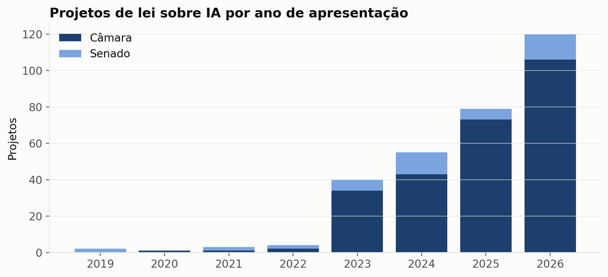

## Falsos positivos da busca

A busca por palavra-chave depende de um indexador. Alguns projetos **não tratam de IA**:

```python
ref = pd.read_csv("dados/anotacoes/referencia_completa.csv")
outros = corpus.merge(ref, on="doc_id").query("categoria == 'OUTRO'")
print(len(outros), "proposições classificadas como OUTRO na referência\n")
for _, r in outros.head(4).iterrows():
    print(f"{r.doc_id}: {r.ementa[:105]}...")
```

```
45 proposições classificadas como OUTRO na referência

doc0009: Institui a Política Nacional de Educação Digital; altera as Leis nºs 9.394, de 20 de dezembro de 1996 (Le...
doc0010: Dispõe sobre a reforma da Lei nº 9.784/99 (Lei de Processo Administrativo)....
doc0030: Altera a Lei 9.434, de 4 de fevereiro de 1997, que “dispõe sobre a remoção de órgãos, tecidos e partes do...
doc0048: Altera o Decreto-Lei nº 2.848, de 7 de dezembro de 1940 (Código Penal), para aumentar as penas dos crimes...
```

→ Viram a categoria **OUTRO** no livro de códigos (o bloco 2 detalha o que entrou nela).

## Recoleta (08/10 × 06/11/2026): a fonte muda

```python
antigo = pd.read_csv("dados/processado/historico/corpus_2026-10-08.csv")
novos = corpus[~corpus["identificacao"].isin(antigo["identificacao"])]
comum = antigo.merge(corpus, on="identificacao", suffixes=("_a", "_n"))
muda = lambda v: int((comum[v + "_a"].fillna("") != comum[v + "_n"].fillna("")).sum())
print(f"Projetos novos: {len(novos)} | saíram: {(~antigo.identificacao.isin(corpus.identificacao)).sum()}")
print(f"Ementas que mudaram: {muda('ementa')} | partidos: {muda('partido')}"
      f" | situação de tramitação: {muda('situacao')} de {len(comum)}")
novos[["doc_id", "casa", "identificacao", "data_apresentacao"]]
```

```
Projetos novos: 6 | saíram: 0
Ementas que mudaram: 0 | partidos: 0 | situação de tramitação: 46 de 298
```

|  | doc_id | casa | identificacao | data_apresentacao |
| --- | --- | --- | --- | --- |
| 298 | doc0299 | Câmara | PL 5580/2026 | 2026-10-15 |
| 299 | doc0300 | Câmara | PL 5606/2026 | 2026-10-19 |
| 300 | doc0301 | Câmara | PL 5715/2026 | 2026-10-30 |
| 301 | doc0302 | Câmara | PL 5716/2026 | 2026-10-30 |
| 302 | doc0303 | Senado | PL 5726/2026 | 2026-11-03 |
| 303 | doc0304 | Câmara | PL 5729/2026 | 2026-11-03 |

## A coleta também é medição

- **Limite de 3 meses** no filtro de data → filtrar por `ano`
- **Partido “na data”**: registros de 2023 para legislaturas antigas → filtro por `situacao`
- **Busca por palavra-chave**: falsos positivos (e omissões que não vemos)
- **Duplicatas**: PL do Senado remetido à Câmara aparece nas duas casas
- **Erros transitórios** (504): repetir a requisição, com espera
- **Campo político**: uma classificação, com escolhas

## Resumo do bloco 1

**O que fizemos**

- Lemos as funções de coleta (`req_json`, paginação, autor, **partido na data**)
- Reconstruímos as **304 proposições** a partir de `dados/bruto/`, idênticas ao corpus oficial
- Vimos que **cada passo da coleta é uma decisão de medição**

**Por que congelar os dados**

APIs mudam: em um mês, 6 projetos novos e dezenas de situações de tramitação alteradas. A replicação parte de `dados/bruto/` e `dados/processado/corpus.csv`, **com data de coleta**.

# 2 · Codificar é medir

`CODEBOOK.md` · `dados/anotacoes/referencia_completa.csv`

## O que vamos executar neste bloco

1. Ler o **livro de códigos**: categorias, regras de decisão, variável eleitoral
2. Olhar **ementas difíceis**, em que as regras importam
3. Carregar a **referência**: quem a fez, como, e seu status
4. Contar **quantos de cada classe** e ver **o que foi parar em OUTRO**
5. Carregar a **amostra-ouro** e verificar se ela **representa** o corpus

## Livro de códigos

| Código | Instrumento central | Exemplo |
| --- | --- | --- |
| **PUNIR** | penal: crime, pena, Código Penal | “tipifica o crime de deepfake sexual” |
| **REGULAR** | regras não penais: deveres, rotulagem, direitos | “obriga identificar conteúdo gerado por IA” |
| **PROMOVER** | fomento, ensino, adoção pelo Estado | “inclui IA no currículo do ensino médio” |
| **OUTRO** | não trata de IA | falsos positivos da busca |

Unidade de análise: a **ementa**, e só ela (sem inteiro teor, sem autor, para não “adivinhar” pelo partido).

## Regras de decisão

1. **Precedência:** PUNIR > REGULAR > PROMOVER
2. “Responsabilização” ou “penalidades” **sem** crime, pena ou Código Penal → **REGULAR**
3. **Marcos gerais** (“princípios, direitos e deveres”) → REGULAR
4. **Proteção de trabalhadores** diante da automação → REGULAR
5. **Obrigar o Estado ou empresas a usar IA** → PROMOVER
6. **Deepfake, montagem, nudez falsa** = conteúdo sintético, mesmo sem a palavra “IA”
7. Na dúvida com OUTRO: *a ementa, sozinha, deixa claro que o objeto é IA?*

## A variável eleitoral

**`eleitoral` = 1** se a ementa trata de eleições, campanhas, propaganda eleitoral, candidatos, Código Eleitoral, violência política ou processo democrático.

- É **independente** da categoria: um PL pode ser PUNIR e eleitoral
- É **rara**: poucas ementas na amostra-ouro → métricas imprecisas

```python
ref["eleitoral"].value_counts().rename({0: "não eleitoral", 1: "eleitoral"})
```

```
eleitoral
não eleitoral    291
eleitoral         13
Name: count, dtype: int64
```

## Ementas difíceis: “penalidades” e “responsabilização”

```python
dificeis = (corpus.merge(ref, on="doc_id")
            .loc[lambda d: d["ementa"].str.contains("penalidade|responsabiliza", case=False)])
for _, r in dificeis.head(4).iterrows():
    print(f"[{r.categoria:<8}] {r.ementa[:120]}...\n")
```

```
[PUNIR   ] Altera o Decreto-Lei nº 2.848, de 7 de dezembro de 1940 (Código Penal), a Lei nº 4.737, de 15 de julho de 1965 (Código E...

[PUNIR   ] Dispõe sobre a responsabilização do crime de manipulação de imagem de forma não autorizada....

[REGULAR ] Dispõe sobre a regulação do uso de deepfakes, estabelece penalidades para usos prejudiciais e incentiva o desenvolviment...

[REGULAR ] Dispõe sobre a obrigatoriedade de advertências, recomendações etárias e limites de uso consciente de ferramentas de inte...
```

**Dica**

A palavra “penalidade” **não** basta para PUNIR: é preciso crime, pena ou Código Penal.

## A referência no arquivo

```python
print(ref.shape)
ref.head(4)
```

```
(304, 6)
```

|  | doc_id | categoria | eleitoral | codificador | revisado | obs |
| --- | --- | --- | --- | --- | --- | --- |
| 0 | doc0001 | REGULAR | 0 | preliminar | False | NaN |
| 1 | doc0002 | PROMOVER | 0 | preliminar | False | NaN |
| 2 | doc0003 | REGULAR | 0 | preliminar | False | NaN |
| 3 | doc0004 | REGULAR | 0 | preliminar | False | NaN |

```python
ref[["codificador", "revisado"]].value_counts()
```

```
codificador  revisado
preliminar   False       304
Name: count, dtype: int64
```

**Aviso**

A referência deste material é **preliminar** (`revisado = False`). Os números de hoje **ensinam o método**; não são achados definitivos.

## De onde vêm os rótulos de referência?

- As 304 ementas têm um rótulo de **referência** (`dados/anotacoes/referencia_completa.csv`): é a “régua” do minicurso
- **Quem codificou:** outra IA, o **Claude Opus 5.5** (Anthropic), coautor deste material. **Não** é o S5-nano, o instrumento que vamos avaliar
- **Como:** aplicando o **livro de códigos** ementa por ementa, lendo **só a ementa** (sem autor, sem inteiro teor); os casos ambíguos ficaram anotados para discussão (ex.: doc0121, doc0185, doc0233)
- **Quando:** 298 ementas da coleta de 08/10/2026 e as 6 novas da coleta de 06/11/2026
- **Status:** **preliminar**, ainda **sem revisão humana** (`codificador = "preliminar"`, `revisado = False`)

**O que isso muda**

Sem revisão humana, o kappa do bloco 5 mede a concordância **entre duas IAs** (S5-nano × Claude), não a validade contra humanos. Se as duas erram nos mesmos casos, a concordância **infla**.

Os números **ensinam o método**; não são achados sobre o Congresso.

**Pergunta para a turma**

Por que não aceitar o rótulo do Claude como “verdade” e dispensar os humanos?

## Quantos de cada classe?

```python
d = corpus.merge(ref, on="doc_id")
tab = pd.crosstab(d["categoria"], d["casa"]).loc[CATEGORIAS]
tab["Total"] = tab.sum(axis=1)
tab["%"] = (100 * tab["Total"] / tab["Total"].sum()).round(1)
tab
```

| casa categoria | Câmara | Senado | Total | % |
| --- | --- | --- | --- | --- |
| PUNIR | 40 | 13 | 53 | 17.4 |
| REGULAR | 136 | 14 | 150 | 49.3 |
| PROMOVER | 47 | 9 | 56 | 18.4 |
| OUTRO | 37 | 8 | 45 | 14.8 |

- **Total:** 304 ementas · **REGULAR é metade** do corpus: chutar sempre REGULAR é o **piso** de qualquer instrumento
- **Eleitoral = 1** é **rara** (13 ementas): métricas para ela serão imprecisas

## O que foi parar em OUTRO?

45 ementas (14,8% do corpus, 32 delas de 2026) vieram na busca, mas a **ementa, sozinha, não trata de IA nem de conteúdo sintético** (regra 7).

| Tipo | Exemplos reais do corpus (ementas resumidas) |
| --- | --- |
| **Temas digitais vizinhos**, sem IA na ementa | violência contra a mulher em ambiente digital · crimes cibernéticos · LGPD para crianças · inclusão e soberania digital · nuvem soberana |
| **Leis penais** que não citam IA nem conteúdo sintético | aumento de pena dos arts. 216-B e 218-C do Código Penal · estelionato · usura · ameaça pelo Pix |
| **Falsos positivos puros** | Lei Geral das Atividades Nucleares · transplante de órgãos · Código de Trânsito · processo administrativo |

**Por que vieram?** A busca das APIs não olha só a ementa (o indexador usa também outros campos, como a indexação do projeto), e o texto completo pode até tratar de IA. Mas a unidade de análise é a **ementa**.

**Pergunta para a turma**

A proporção PUNIR deve ser calculada sobre as 304 ementas ou só sobre as que tratam de IA?

Sobre 304: 17,4% · sobre 259: 20,5%. O denominador é uma **decisão de medição** (aqui, as 304).

## A amostra-ouro

- **Aleatória:** nem as “mais fáceis”, nem as “mais interessantes”
- **Tamanho:** n = 120 (~40% do corpus), decisão de custo × precisão
- Sorteada com semente fixa (2026) em `R/02_amostra_ouro.R`

```python
ouro = carrega_ouro(".")
print(len(ouro), "ementas na amostra-ouro")
ouro["categoria"].value_counts()
```

```
AVISO: a amostra-ouro ainda NÃO foi revisada por humanos (coluna `revisado`). Os resultados são ilustrativos.
120 ementas na amostra-ouro
```

```
categoria
REGULAR     69
PUNIR       22
PROMOVER    16
OUTRO       13
Name: count, dtype: int64
```

R e Python sorteiam diferente com a mesma semente: o Python **lê** a amostra sorteada em R.

## A amostra-ouro representa o corpus?

```python
comp = pd.DataFrame({
    "corpus (referência)": ref["categoria"].value_counts(normalize=True),
    "amostra-ouro": ouro["categoria"].value_counts(normalize=True)}).loc[CATEGORIAS]
comp.style.format("{:.1%}")
```

| categoria | corpus (referência) | amostra-ouro |
| --- | --- | --- |
| PUNIR | 17.4% | 18.3% |
| REGULAR | 49.3% | 57.5% |
| PROMOVER | 18.4% | 13.3% |
| OUTRO | 14.8% | 10.8% |

```python
campo_ouro = corpus.merge(ouro[["doc_id"]], on="doc_id")["campo"].value_counts(normalize=True)
pd.DataFrame({"corpus": corpus["campo"].value_counts(normalize=True),
              "amostra-ouro": campo_ouro}).style.format("{:.1%}")
```

| campo | corpus | amostra-ouro |
| --- | --- | --- |
| Direita | 51.0% | 43.3% |
| Esquerda | 26.3% | 27.5% |
| Centro | 20.1% | 25.8% |
| Sem partido/Outro | 2.6% | 3.3% |

## Quanto **nós** concordamos?

**Levantem a mão:** PUNIR, REGULAR, PROMOVER ou OUTRO?

1. *“Estabelece condições, deveres e restrições ao uso de óculos inteligentes com recursos de inteligência artificial, altera o Código de Trânsito Brasileiro e o Código Penal…”* (doc0185)
2. *“Dispõe sobre medidas de prevenção, combate e responsabilização relacionadas à criação e disseminação de manipulação digital de conteúdo sexual (deepfakes)…”* (doc0233)

Referência: 1 → **PUNIR** (altera o Código Penal; PUNIR precede REGULAR) · 2 → **REGULAR** (“responsabilização” sem crime nem pena; regra 2). A sala se dividiu? É essa divergência que o **alfa entre codificadores** mede.

**Por que isso importa**

Se humanos treinados não concordam, o LLM **não tem alvo**. A concordância humana é o **teto** realista do instrumento.

Neste material ainda não há dois codificadores humanos: o teto é **desconhecido**.

## Medindo a concordância: alfa de Krippendorff

Com dois ou mais codificadores, o alfa mede a concordância além do acaso. Um exemplo com três codificadores fictícios:

```python
respostas = pd.DataFrame({
    "ana":   ["PUNIR", "REGULAR", "REGULAR", "PROMOVER", "OUTRO",  "REGULAR"],
    "bruno": ["PUNIR", "REGULAR", "PUNIR",   "PROMOVER", "OUTRO",  "PROMOVER"],
    "carla": ["PUNIR", "REGULAR", "REGULAR", "REGULAR",  None,     "REGULAR"]},
    index=[f"doc{i}" for i in range(1, 7)])
print(respostas)
print(f"\nAlfa de Krippendorff: {alfa_krippendorff(respostas):.3f}")
```

```
           ana     bruno    carla
doc1     PUNIR     PUNIR    PUNIR
doc2   REGULAR   REGULAR  REGULAR
doc3   REGULAR     PUNIR  REGULAR
doc4  PROMOVER  PROMOVER  REGULAR
doc5     OUTRO     OUTRO     None
doc6   REGULAR  PROMOVER  REGULAR

Alfa de Krippendorff: 0.510
```

## Resumo do bloco 2

**O que fizemos**

- Um conceito só pode ser medido se tiver **definição operacional** escrita (o livro de códigos)
- A referência foi feita por **outra IA** (Claude Opus 5.5) e ainda **não foi revisada por humanos**
- Metade do corpus é REGULAR; OUTRO reúne o que a busca trouxe sem tratar de IA na ementa
- A **amostra-ouro** aleatória é a régua contra a qual tudo será avaliado, e sua distribuição é próxima à do corpus
- A **concordância humana** define o teto do instrumento automático

# 3 · Baselines

`python/02_baselines.ipynb`

## O que vamos executar neste bloco

1. **Dicionário**: expressões regulares que traduzem o livro de códigos
2. **Métricas** implementadas “na mão”: acurácia, F1 macro, kappa de Cohen
3. **TF-IDF + regressão logística**, com validação cruzada de 10 dobras
4. Comparar com a **classe majoritária**

**Pergunta do bloco**

**Quanto se acerta sem LLM?** Um LLM só vale a pena se superar instrumentos mais baratos e transparentes, e isso é uma afirmação **estatística**.

## Dicionário: as expressões regulares

```python
for nome, padrao in REGEX.items():
    print(f"{nome.upper():<10} {padrao[:95]}")
    if len(padrao) > 95:
        print(" " * 11 + padrao[95:190])
```

```
PUNIR      c[oó]digo penal|\bpenas?\b|\bcrimes?\b|criminaliz|tipific|hediond
IA         intelig[eê]ncia artificial|\bia\b|algor[ií]tm|automatiz|automa[cç][aã]o|sint[eé]tic|deep ?fake|
           deepvoice|manipula|chatbot|reconhecimento facial|aut[oô]nom|\binteligente|réplicas? digit|simul
PROMOVER   incentiv|fomento|\bfundo\b|curr[ií]cul|ensino|educa[cç]|capacita|forma[cç][aã]o|pesquisa|desenv
           olvimento da|programa nacional|institui o sistema|obrigatoriedade d[eo] uso|utiliza[cç][aã]o de
ELEITORAL  elei[cç]|eleitora|campanhas? eleitora|candidat|propaganda pol|democr|violência política
```

- `punir`: vocabulário penal · `ia`: a ementa trata de IA? · `promover`: fomento e uso
- Totalmente **auditável**: qualquer pessoa lê e discorda das regras

## `classifica_dicionario`

```python
def classifica_dicionario(ementa):
    x = ementa.lower()
    tem_ia = re.search(REGEX["ia"], x)
    if re.search(REGEX["punir"], x) and tem_ia:
        return "PUNIR"
    if not tem_ia:
        return "OUTRO"
    if re.search(REGEX["promover"], x):
        return "PROMOVER"
    return "REGULAR"
```

A **ordem** das regras implementa a precedência do livro de códigos: PUNIR > (não é IA → OUTRO) > PROMOVER > REGULAR.

## O dicionário em ação

```python
ouro = ouro.merge(corpus[["doc_id", "ementa"]], on="doc_id")
ouro["pred_dic"] = ouro["ementa"].map(classifica_dicionario)
for _, r in ouro.sample(6, random_state=3).iterrows():
    ok = "✓" if r.categoria == r.pred_dic else "✗"
    print(f"{ok} humano={r.categoria:<8} dic={r.pred_dic:<8} {r.ementa[:75]}...")
```

```
✗ humano=PROMOVER dic=REGULAR  Altera a Lei nº 12.651, de 25 de maio de 2012 (Código Florestal), para inst...
✓ humano=REGULAR  dic=REGULAR  Estabelece complementações ao regime nacional de governança da inteligência...
✗ humano=REGULAR  dic=PROMOVER Dispõe sobre normas gerais para a pesquisa, o desenvolvimento e a aplicação...
✓ humano=PUNIR    dic=PUNIR    Altera o Decreto-Lei nº 2.848, de 7 de dezembro de 1940 (Código Penal), par...
✓ humano=REGULAR  dic=REGULAR  Altera a Medida Provisória nº 2.228-1, de 6 de setembro de 2001, para regul...
✓ humano=REGULAR  dic=REGULAR  Esta Lei torna obrigatória a disponibilização, por parte das empresas que o...
```

## Métricas: acurácia, F1 e kappa

- **Acurácia**: proporção de acertos. Engana quando as classes são desbalanceadas
- **F1 macro**: média do F1 de cada categoria; categorias raras pesam igual
- **Kappa de Cohen**: acerto **além do acaso**

$$\kappa = \frac{p_o - p_e}{1 - p_e}
\qquad
p_e = \sum_c \frac{n_{c\cdot}}{n}\,\frac{n_{\cdot c}}{n}$$

Landis & Koch: **0,4** moderada · **0,6** substancial · **0,8** quase perfeita

## Kappa “na mão”

```python
def kappa_cohen(a, b):
    a, b = _validos(a, b)                 # descarta pares com NA
    n = len(a)
    po = np.mean(a == b)
    pe = sum(np.sum(a == c) * np.sum(b == c) for c in CATEGORIAS) / n ** 2
    if n == 0 or pe == 1:                 # indefinido (ex.: uma só categoria)
        return float("nan")
    return (po - pe) / (1 - pe)
```

```python
humano = ["PUNIR", "REGULAR", "REGULAR", "REGULAR", "PROMOVER", "REGULAR"]
chute  = ["REGULAR"] * 6                       # sempre a classe mais comum
quase  = ["PUNIR", "REGULAR", "REGULAR", "PROMOVER", "PROMOVER", "REGULAR"]
print(f"chute: acurácia {np.mean(np.array(humano) == chute):.2f}, kappa {kappa_cohen(humano, chute):.2f}")
print(f"quase: acurácia {np.mean(np.array(humano) == quase):.2f}, kappa {kappa_cohen(humano, quase):.2f}")
```

```
chute: acurácia 0.67, kappa 0.00
quase: acurácia 0.83, kappa 0.71
```

## O dicionário na amostra-ouro

```python
met_dic = resumo_metricas(ouro["categoria"], ouro["pred_dic"])
{k: round(v, 3) for k, v in met_dic.items()}
```

```
{'n': 120,
 'falhas_formato': 0.0,
 'acuracia': 0.808,
 'f1_macro': 0.782,
 'kappa': 0.699}
```

```python
pd.crosstab(ouro["categoria"], ouro["pred_dic"], rownames=["humano"], colnames=["dicionário"])
```

| dicionário humano | OUTRO | PROMOVER | PUNIR | REGULAR |
| --- | --- | --- | --- | --- |
| OUTRO | 11 | 1 | 0 | 1 |
| PROMOVER | 0 | 11 | 0 | 5 |
| PUNIR | 2 | 0 | 20 | 0 |
| REGULAR | 2 | 11 | 1 | 55 |

## TF-IDF: a intuição

Cada ementa vira um **vetor de pesos de palavras**:

$$\text{tfidf}(t, d) = \text{tf}(t, d) \times \left[\log\frac{1 + N}{1 + \text{df}(t)} + 1\right]$$

- **tf**: quantas vezes o termo aparece na ementa
- **idf**: termos que aparecem em **todas** as ementas (“dispõe”, “lei”) pesam pouco
- Removemos *stopwords* em português e números; termos em menos de 2 ementas saem

Depois, uma **regressão logística multinomial** aprende a mapear o vetor na categoria.

## Vetorização

```python
from sklearn.feature_extraction.text import TfidfVectorizer
vet = TfidfVectorizer(lowercase=True, stop_words=STOPWORDS_PT, min_df=2,
                      token_pattern=r"(?u)\b[^\W\d_]{2,}\b")
X = vet.fit_transform(ouro["ementa"])
print("Matriz documento-termo:", X.shape, f"· {X.nnz / np.prod(X.shape):.1%} preenchida")
idf = pd.Series(vet.idf_, index=vet.get_feature_names_out()).sort_values()
print("Termos mais comuns (idf baixo):", ", ".join(idf.index[:8]))
print("Termos mais raros  (idf alto): ", ", ".join(idf.index[-8:]))
```

```
Matriz documento-termo: (120, 313) · 5.1% preenchida
Termos mais comuns (idf baixo): artificial, inteligência, lei, altera, sobre, nº, outras, providências
Termos mais raros  (idf alto):  preservação, prestação, falso, falsas, prevê, privacidade, econômica, mercado
```

- 120 ementas, centenas de termos: **muito mais variáveis que observações**
- Por isso a regressão precisa de **penalização** (regularização)

## O modelo e a validação cruzada

```python
from sklearn.linear_model import LogisticRegressionCV
from sklearn.model_selection import StratifiedKFold, cross_val_predict
from sklearn.pipeline import make_pipeline

modelo = make_pipeline(
    TfidfVectorizer(lowercase=True, stop_words=STOPWORDS_PT, min_df=2,
                    token_pattern=r"(?u)\b[^\W\d_]{2,}\b"),
    LogisticRegressionCV(Cs=10, cv=5, max_iter=5000, scoring="accuracy"))
dobras = StratifiedKFold(n_splits=10, shuffle=True, random_state=2026)
ouro["pred_ml"] = cross_val_predict(modelo, ouro["ementa"], ouro["categoria"], cv=dobras)
pd.crosstab(ouro["categoria"], ouro["pred_ml"], rownames=["humano"], colnames=["TF-IDF"])
```

| TF-IDF humano | OUTRO | PROMOVER | PUNIR | REGULAR |
| --- | --- | --- | --- | --- |
| OUTRO | 1 | 3 | 0 | 9 |
| PROMOVER | 2 | 8 | 0 | 6 |
| PUNIR | 1 | 0 | 16 | 5 |
| REGULAR | 2 | 3 | 2 | 62 |

- Previsões *out-of-fold*; o vetorizador fica **dentro** do pipeline (o idf também só vê o treino)

## Resultados dos baselines

```python
maj = ["REGULAR"] * len(ouro)
baselines = pd.DataFrame([
    {"metodo": "Dicionário (regex)", **resumo_metricas(ouro["categoria"], ouro["pred_dic"])},
    {"metodo": "TF-IDF + logística (CV 10)", **resumo_metricas(ouro["categoria"], ouro["pred_ml"])},
    {"metodo": "Classe majoritária (REGULAR)", **resumo_metricas(ouro["categoria"], maj)},
]).set_index("metodo")
baselines.round(3)
```

| metodo | n | falhas_formato | acuracia | f1_macro | kappa |
| --- | --- | --- | --- | --- | --- |
| Dicionário (regex) | 120 | 0.0 | 0.808 | 0.782 | 0.699 |
| TF-IDF + logística (CV 10) | 120 | 0.0 | 0.725 | 0.565 | 0.508 |
| Classe majoritária (REGULAR) | 120 | 0.0 | 0.575 | 0.183 | 0.000 |

## Acurácia engana

- Chutar **sempre REGULAR** acerta **57,5%** das ementas
- Mas o kappa é **0,00**: não acerta nada além do que o acaso já acertaria
- O F1 macro (0,18) também denuncia: as categorias raras são ignoradas

**Importante**

Com classes desbalanceadas, relate **kappa e F1 macro**, não só acurácia.

## O dicionário “viu a prova”

**Data leakage**

As regras do dicionário foram escritas **depois de ler as ementas** do corpus. Seu desempenho é **otimista**.

- Num estudo real, as regras são definidas **antes**, ou validadas em **dados novos** (ex.: proposições apresentadas depois da coleta)
- O mesmo vale para o LLM: os exemplos do prompt v3 são **fictícios** de propósito
- E para a escolha do modelo: usar a amostra-ouro para escolher o melhor torna o kappa do vencedor otimista

## O “mesmo” método, implementações diferentes

```python
base_r = pd.read_csv("resultados/tabelas/baselines.csv").set_index("metodo")
pd.DataFrame({"kappa em R (glmnet)": base_r["kappa"],
              "kappa em Python (scikit-learn)": baselines["kappa"]}).round(3)
```

| metodo | kappa em R (glmnet) | kappa em Python (scikit-learn) |
| --- | --- | --- |
| Dicionário (regex) | 0.699 | 0.699 |
| TF-IDF + logística (CV 10) | 0.407 | 0.508 |
| Classe majoritária (REGULAR) | 0.000 | 0.000 |

- Dicionário: **idêntico** nas duas linguagens (as mesmas regras)
- TF-IDF: R usa **elastic-net + stemming**; Python usa **L2, sem stemming**
- “TF-IDF + logística” **não é um método**: é uma família de escolhas, e cada escolha precisa ser relatada

## Resumo do bloco 3

**O que fizemos**

- Dicionário: kappa **0,70** (otimista: viu a prova)
- TF-IDF + logística: kappa **0,51** com 120 exemplos
- Classe majoritária: acurácia alta, kappa **zero**

**Para discutir:** quantos exemplos rotulados o TF-IDF precisaria para superar as regras? Quanto custa produzi-los?

# 4 · O LLM como instrumento

`python/03_anotacao_llm.ipynb` · `python/anotar_llm.py`

## O que vamos executar neste bloco

1. Subir o **modelo local** no Ollama e entender o **Modelfile**
2. Ler a **chamada** ao modelo: esquema JSON, temperatura, semente, modo *instruct*
3. Ler os **três prompts** e calcular a **impressão digital** (hash) de cada um
4. Extrair rótulos de respostas “sujas”
5. Entender o **laço de anotação com cache**
6. Explorar as **1.824 respostas** guardadas em `dados/cache_llm/`

## Ollama: um servidor de modelos local

```bash
# 1. instalar: https://ollama.com (Linux, macOS, Windows; no Colab, célula do notebook 03)
# 2. baixar o S5-nano em 4 bits (~3,5 GB) direto do Hugging Face
ollama pull hf.co/maritaca-ai/S5-nano-GGUF:Q4_K_M
# 3. dar a ele um nome local estável
ollama create s5-nano-instruct -f modelos/Modelfile.s5-nano-instruct
# 4. o servidor responde em http://localhost:11434
```

- **Local:** os dados não saem da máquina · custo zero · **a versão não muda sem aviso**
- O Ollama expõe uma **API HTTP**: qualquer linguagem conversa com ele (Python, R, curl)

## O Modelfile

```python
print(open("modelos/Modelfile.s5-nano-instruct", encoding="utf-8").read())
```

```
# S5-nano (Maritaca AI) em modo INSTRUCT: o instrumento de medição do minicurso.
#
# Pesos: GGUF oficial quantizado em 4 bits (Q4_K_M, ~2,8 GB + 0,7 GB do módulo de visão),
# licença Apache-2.0: https://huggingface.co/maritaca-ai/S5-nano-GGUF
#
# Criar (uma vez):
#   ollama pull hf.co/maritaca-ai/S5-nano-GGUF:Q4_K_M
#   ollama create s5-nano-instruct -f modelos/Modelfile.s5-nano-instruct
#
# A Maritaca publica UM modelo com dois modos: "think" (raciocina antes de responder) e
# "instruct" (responde direto). O modo é escolhido em cada chamada: o template oficial,
# embutido no GGUF, abre o bloco <think> vazio quando o cliente envia "think": false.
# Por isso o modo instruct é garantido pelo código (python/anotar_llm.py e
# R/04_anotacao_llm.R enviam sempre "think": false e rejeitam respostas com raciocínio),
# e não por este arquivo.
#
# Temperatura, semente e demais opções também NÃO ficam aqui: o código envia tudo
# explicitamente em cada chamada (e registra no cache), para o instrumento ser auditável.
FROM hf.co/maritaca-ai/S5-nano-GGUF:Q4_K_M
```

## Por que o S5-nano?

- **Brasileiro:** desenvolvido pela Maritaca AI, com pré-treinamento adicional em **dados em português**, a língua (e o vocabulário jurídico-legislativo) das ementas
- **Vem do Qwen:** parte do **Qwen3.5-4B** (Alibaba) e herda a arquitetura, o tokenizador e boa parte do que “sabe”
- **Aberto e pequeno:** Apache-2.0, pesos públicos (todos baixam **a mesma versão**), roda numa GPU de notebook
- A origem faz parte da descrição do instrumento, e “brasileiro” **não garante validade**: é preciso medir na amostra-ouro

## Quantização: outro instrumento

- Pesos originais em **BF16** (16 bits): ~8 GB
- Versão **Q4_K_M** (4 bits): ~2,8 GB + 0,7 GB do módulo de visão
- Cabe numa GPU de notebook com **6 GB**
- O modelo quantizado **não é o mesmo instrumento** que o original

**Aviso**

Os resultados que a Maritaca publica foram obtidos com os pesos completos. O que vale para este material é a **validação feita aqui**, com o modelo que de fato usamos.

## O Ollama está respondendo?

```python
import requests
OLLAMA = os.environ.get("OLLAMA_HOST", "http://localhost:11434")
for m in requests.get(f"{OLLAMA}/api/tags", timeout=5).json()["models"]:
    print(m["name"], m["digest"][:12], m["details"]["parameter_size"],
          m["details"]["quantization_level"], m["details"]["parent_model"])
print("Ollama", requests.get(f"{OLLAMA}/api/version").json()["version"])
```

```
s5-nano-instruct:latest 85ec77c8f04e 4.33B Q4_K_M hf.co/maritaca-ai/S5-nano-GGUF:Q4_K_M
Ollama 0.40.15
```

- O **digest** (`85ec77c8f04e`) identifica os pesos; o nome `s5-nano-instruct` é só um apelido local
- A **versão do Ollama** também faz parte do instrumento

## A chamada ao modelo

```python
def chama_ollama(modelo, prompt, temperatura, semente, timeout=120):
    r = requests.post(f"{OLLAMA}/api/chat", json={
            "model": modelo,
            "stream": False,
            "think": False,                    # modo instruct: responde sem "raciocinar"
            "format": ESQUEMA,                 # saída estruturada (JSON)
            "options": {"temperature": temperatura, "seed": semente},  # registrar SEMPRE
            "messages": [{"role": "user", "content": prompt}],
        }, timeout=timeout)
    r.raise_for_status()
    msg = r.json()["message"]
    if msg.get("thinking"):
        raise RuntimeError("o modelo devolveu raciocínio: o modo instruct não foi respeitado")
    return msg["content"]
```

- Se vier raciocínio, **para com erro**, em vez de registrar em silêncio outro instrumento

## Saída estruturada: o esquema JSON

```python
import anotar_llm as al
print(json.dumps(al.ESQUEMA, ensure_ascii=False))
```

```
{"type": "object", "properties": {"categoria": {"type": "string", "enum": ["PUNIR", "REGULAR", "PROMOVER", "OUTRO"]}, "eleitoral": {"type": "boolean"}}, "required": ["categoria", "eleitoral"]}
```

- `categoria` restrita às **quatro** categorias (`enum`) · `eleitoral` verdadeiro/falso
- O Ollama **força** o modelo a gerar texto compatível com o esquema
- **Temperatura 0**: sempre o token mais provável (deveria ser determinístico; veremos no bloco 7 que não é bem assim) · **> 0**: sorteio controlado pela **semente** (usamos t = 0,8 com sementes 1, 2, 3 no teste-reteste)
- Temperatura e semente são parâmetros **do instrumento**: vão em cada registro do cache

## O prompt é parte do instrumento

```python
for pid, arq in al.PROMPTS.items():
    texto = arq.read_text(encoding="utf-8")
    print(f"{pid}: {arq.name:<24} {len(texto):>5} caracteres  sha256={al.sha(texto)}")
```

```
v1: prompt_v1_simples.txt      252 caracteres  sha256=5eb0f92ea13d
v2: prompt_v2_codebook.txt    1522 caracteres  sha256=c4b5a5ade801
v3: prompt_v3_fewshot.txt     2485 caracteres  sha256=6fdbfaf1d613
```

| Versão | Conteúdo | Motivação |
| --- | --- | --- |
| **v1** | só os nomes das categorias | o que o modelo “entende” sozinho? |
| **v2** | + definições e regras do livro de códigos | aproximar do codificador treinado |
| **v3** | + 6 exemplos **fictícios** (*few-shot*) | exemplos ajudam nos casos ambíguos? |

## Prompt v1: só os nomes

```python
print(al.PROMPTS["v1"].read_text(encoding="utf-8"))
```

```
Classifique a ementa de projeto de lei abaixo em UMA categoria: PUNIR, REGULAR, PROMOVER ou OUTRO.
Indique também se o tema é eleitoral (true/false).
Responda apenas em JSON no formato {"categoria": "...", "eleitoral": true/false}.

Ementa: {{ementa}}
```

O modelo precisa **adivinhar** o que queremos dizer com PUNIR, REGULAR e PROMOVER.

## Prompt v2: o livro de códigos

```python
v2 = al.PROMPTS["v2"].read_text(encoding="utf-8")
print(v2[:v2.index("ELEITORAL")])
```

```
Você é um codificador de pesquisa em Ciência Política. Classifique a ementa de um projeto de lei brasileiro segundo o livro de códigos abaixo. Use APENAS o texto da ementa.

CATEGORIAS (escolha exatamente uma):
- PUNIR: o instrumento central é penal: cria crime, tipifica conduta, criminaliza, aumenta ou qualifica pena, altera o Código Penal, a parte penal do ECA ou cria crime eleitoral.
- REGULAR: estabelece regras não penais para o uso de IA: princípios, deveres, obrigações, proibições administrativas, direitos, transparência, rotulagem, auditoria, responsabilidade civil ou administrativa, proteção de dados, direitos autorais, proteção do consumidor ou do trabalhador, campanhas de…
- PROMOVER: fomenta ou adota IA: incentivos, fundos, pesquisa, ensino de IA em currículos, capacitação, ou uso de IA pelo Estado em políticas públicas.
- OUTRO: a ementa não trata de IA, algoritmos, automação ou conteúdo sintético/manipulado digitalmente.

REGRAS:
1. Se houver mais de um instrumento, a precedência é PUNIR > REGULAR > PROMOVER.
2. "Responsabilização" ou "penalidades" sem menção a crime, pena ou Código Penal = REGULAR.
3. Deepfake, montagem ou nudez falsa contam como conteúdo sintético.
```

## Prompt v3: exemplos fictícios

```python
v3 = al.PROMPTS["v3"].read_text(encoding="utf-8")
ini = v3.index("Ementa: \"")
print(v3[ini:v3.index("Responda apenas", ini)].strip())
```

```
Ementa: "Altera o Código Penal para tipificar a clonagem de voz por inteligência artificial com fins de extorsão."
{"categoria": "PUNIR", "eleitoral": false}
Ementa: "Obriga plataformas digitais a rotular conteúdos gerados por inteligência artificial durante o período de campanha eleitoral."
{"categoria": "REGULAR", "eleitoral": true}
Ementa: "Cria o Programa Nacional de Bolsas para Formação em Inteligência Artificial nas universidades públicas."
{"categoria": "PROMOVER", "eleitoral": false}
Ementa: "Dispõe sobre o uso de sistemas de IA na triagem de pacientes das unidades básicas de saúde."
{"categoria": "PROMOVER", "eleitoral": false}
Ementa: "Estabelece deveres de transparência para chatbots e prevê sanções administrativas ao fornecedor."
{"categoria": "REGULAR", "eleitoral": false}
Ementa: "Altera a Lei nº 9.503 para dispor sobre a renovação da carteira de habilitação de idosos."
{"categoria": "OUTRO", "eleitoral": false}
```

Exemplos **inventados**: usar ementas reais arriscaria vazar casos da amostra-ouro (o mesmo problema do dicionário).

## A impressão digital do prompt

```python
def sha(texto: str) -> str:
    return hashlib.sha256(texto.encode("utf-8")).hexdigest()[:12]
```

```python
texto = al.PROMPTS["v2"].read_text(encoding="utf-8")
print("SHA do arquivo v2:          ", al.sha(texto))
print("SHA com um espaço a mais:   ", al.sha(texto + " "))
cache_v2 = pd.read_json("dados/cache_llm/s5-nano-instruct__v2__t0.0__s42.jsonl", lines=True)
print("SHA registrado no cache v2: ", cache_v2["prompt_sha"].unique())
```

```
SHA do arquivo v2:           c4b5a5ade801
SHA com um espaço a mais:    067151ab68b6
SHA registrado no cache v2:  ['c4b5a5ade801']
```

- Um espaço a mais muda o hash: **qualquer** edição do prompt fica visível
- R e Python calculam **o mesmo hash** (leitura byte a byte do arquivo)

## Extrair o rótulo: respostas “sujas”

```python
def extrai_rotulo(resposta: str):
    m = re.search(r"\{.*?\}", resposta, flags=re.S)        # primeiro objeto JSON
    if not m:
        return None, None
    try:
        d = json.loads(m.group(0))
    except json.JSONDecodeError:
        return None, None
    cat = str(d.get("categoria", d.get("classificacao", ""))).strip().upper()
    ele = d.get("eleitoral")
    if isinstance(ele, str):
        ele = ele.strip().lower() in ("true", "sim", "1")
    return (cat if cat in CATEGORIAS else None), (bool(ele) if ele is not None else None)
```

## Extrair o rótulo: testando

````python
respostas = [
    '{"categoria": "PUNIR", "eleitoral": true}',
    '```json\n{"categoria": "regular", "eleitoral": false}\n```',
    'Claro! A classificação é {"classificacao": "PROMOVER", "eleitoral": "sim"}.',
    '{"categoria": "CRIMINALIZAR", "eleitoral": false}',
    'Não sei classificar esta ementa.',
    'ERRO: HTTPConnectionPool(host=localhost, port=11434): Read timed out.',
]
for r in respostas:
    print(f"{al.extrai_rotulo(r)!s:<22} ← {r[:62]!r}")
````

````
('PUNIR', True)        ← '{"categoria": "PUNIR", "eleitoral": true}'
('REGULAR', False)     ← '```json\n{"categoria": "regular", "eleitoral": false}\n```'
('PROMOVER', True)     ← 'Claro! A classificação é {"classificacao": "PROMOVER", "eleito'
(None, False)          ← '{"categoria": "CRIMINALIZAR", "eleitoral": false}'
(None, None)           ← 'Não sei classificar esta ementa.'
(None, None)           ← 'ERRO: HTTPConnectionPool(host=localhost, port=11434): Read tim'
````

- Extração **tolerante**, mas falhas viram `None` e **são contadas**, nunca descartadas em silêncio

## O laço de anotação com cache

```python
def anota(corpus, modelo, prompt_id, temperatura, semente, pasta="dados/cache_llm"):
    run_id = f"{modelo_tag}__{prompt_id}__t{temperatura}__s{semente}"
    destino = RAIZ / pasta / f"{run_id}.jsonl"
    feitos = {json.loads(l)["doc_id"] for l in destino.open()} if destino.exists() else set()
    modelo_prompt = PROMPTS[prompt_id].read_text(encoding="utf-8")
    pendentes = corpus[~corpus.doc_id.isin(feitos)]          # retoma de onde parou
    with destino.open("a", encoding="utf-8") as f:
        for row in pendentes.itertuples():
            prompt = modelo_prompt.replace("{{ementa}}", row.ementa)
            try:
                bruto = chama_ollama(modelo, prompt, temperatura, semente)
            except Exception as e:                          # registra a falha, não para
                bruto = f"ERRO: {e}"
            cat, ele = extrai_rotulo(bruto)
            f.write(json.dumps({"doc_id": row.doc_id, "run_id": run_id, ...,
                                "resposta_bruta": bruto, "categoria_llm": cat}) + "\n")
```

(versão resumida; o arquivo completo está em `python/anotar_llm.py`)

## Por que JSONL com uma linha por ementa?

1. **Auditoria:** a resposta **bruta** fica guardada, não só o rótulo extraído
2. **Retomada:** interrompeu? Roda de novo e só as **pendentes** vão ao modelo
3. **Coleta nova:** só os projetos **novos** são anotados
4. **Replicação sem o modelo:** quem não tem GPU refaz tudo a partir do cache

```python
import glob
for arq in sorted(glob.glob("dados/cache_llm/*.jsonl")):
    print(f"{arq:<55} {sum(1 for _ in open(arq, encoding='utf-8')):>4} linhas")
```

```
dados/cache_llm/s5-nano-instruct__v1__t0.0__s42.jsonl    304 linhas
dados/cache_llm/s5-nano-instruct__v2__t0.0__s42.jsonl    304 linhas
dados/cache_llm/s5-nano-instruct__v2__t0.8__s1.jsonl     304 linhas
dados/cache_llm/s5-nano-instruct__v2__t0.8__s2.jsonl     304 linhas
dados/cache_llm/s5-nano-instruct__v2__t0.8__s3.jsonl     304 linhas
dados/cache_llm/s5-nano-instruct__v3__t0.0__s42.jsonl    304 linhas
```

## Demonstração ao vivo (5 ementas)

```python
# Semente 7: diferente da oficial (42), para não misturar o teste com o cache do material
arq = al.anota(corpus.head(5), "s5-nano-instruct", "v2", temperatura=0.0, semente=7)
pd.read_json(arq, lines=True)[["doc_id", "categoria_llm", "eleitoral_llm", "segundos"]]
```

As mesmas 5 ementas, na execução oficial (semente 42), lidas do cache:

```python
(cache_v2.head(5).merge(corpus[["doc_id", "ementa"]], on="doc_id")
 [["doc_id", "categoria_llm", "eleitoral_llm", "segundos", "ementa"]])
```

|  | doc_id | categoria_llm | eleitoral_llm | segundos | ementa |
| --- | --- | --- | --- | --- | --- |
| 0 | doc0001 | REGULAR | False | 0.451 | Estabelece os princípios para o uso da Inteligência Artificial no ... |
| 1 | doc0002 | REGULAR | False | 0.384 | Institui a Política Nacional de Inteligência Artificial. |
| 2 | doc0003 | REGULAR | False | 0.383 | Cria a Lei da Inteligência Artificial, e dá outras providências. |
| 3 | doc0004 | REGULAR | False | 0.382 | Dispõe sobre o uso da Inteligência Artificial. |
| 4 | doc0005 | REGULAR | False | 0.385 | Dispõe sobre os princípios, direitos e obrigações na utilização de... |

## Um registro do cache

```python
reg = cache_v2.iloc[32].to_dict()
print(json.dumps(reg, indent=1, ensure_ascii=False, default=str))
```

```
{
 "doc_id": "doc0033",
 "run_id": "s5-nano-instruct__v2__t0.0__s42",
 "modelo": "s5-nano-instruct",
 "modelo_digest": "85ec77c8f04e",
 "ollama_versao": "0.40.15",
 "prompt_id": "v2",
 "prompt_sha": "c4b5a5ade801",
 "temperatura": 0,
 "semente": 42,
 "resposta_bruta": "{\"categoria\": \"PUNIR\", \"eleitoral\": true}",
 "categoria_llm": "PUNIR",
 "eleitoral_llm": true,
 "segundos": 0.41300000000000003,
 "timestamp": "2026-11-12 02:38:53+00:00"
}
```

## O plano de experimentos

`python python/anotar_llm.py --todas` executa:

| Execução | Prompt | Temperatura | Semente | Para quê |
| --- | --- | --- | --- | --- |
| 1 | v1 | 0 | 42 | linha de base do LLM |
| 2 | v2 | 0 | 42 | validade |
| 3 | v3 | 0 | 42 | efeito do *few-shot* |
| 4–6 | v2 | 0,8 | 1, 2, 3 | teste-reteste (confiabilidade) |

6 execuções × 304 ementas = **1.824 respostas**, cerca de 15 min numa RTX 4050

## Carregar todo o cache

```python
llm = carrega_llm(".")
print(llm.shape)
llm.groupby("run_id").agg(n=("doc_id", "size"),
                          falhas=("categoria_llm", lambda s: s.isna().mean()),
                          seg_mediano=("segundos", "median"),
                          ollama=("ollama_versao", "first"),
                          digest=("modelo_digest", "first"))
```

```
(1824, 14)
```

| run_id | n | falhas | seg_mediano | ollama | digest |
| --- | --- | --- | --- | --- | --- |
| s5-nano-instruct__v1__t0.0__s42 | 304 | 0.0 | 0.359 | 0.40.15 | 85ec77c8f04e |
| s5-nano-instruct__v2__t0.0__s42 | 304 | 0.0 | 0.407 | 0.40.15 | 85ec77c8f04e |
| s5-nano-instruct__v2__t0.8__s1 | 304 | 0.0 | 0.356 | 0.40.15 | 85ec77c8f04e |
| s5-nano-instruct__v2__t0.8__s2 | 304 | 0.0 | 0.358 | 0.40.15 | 85ec77c8f04e |
| s5-nano-instruct__v2__t0.8__s3 | 304 | 0.0 | 0.359 | 0.40.15 | 85ec77c8f04e |
| s5-nano-instruct__v3__t0.0__s42 | 304 | 0.0 | 0.439 | 0.40.15 | 85ec77c8f04e |

## Quanto tempo leva?

```python
seg = llm.loc[llm["temperatura"] == 0, "segundos"]
print(f"Por ementa: mediana {seg.median():.2f} s · média {seg.mean():.2f} s · máx {seg.max():.1f} s")
print(f"Corpus inteiro (uma execução): ~{len(corpus) * seg.mean() / 60:.0f} min")
print("Período das anotações:", llm["timestamp"].min()[:16], "→", llm["timestamp"].max()[:16])
```

```
Por ementa: mediana 0.41 s · média 0.40 s · máx 0.9 s
Corpus inteiro (uma execução): ~2 min
Período das anotações: 2026-11-12T02:36 → 2026-11-12T02:48
```

- Num notebook com GPU de 6 GB, **o corpus inteiro em poucos minutos**
- Uma API comercial seria mais rápida, mas **paga** e **mutável**

## Falhas de formato

```python
print("Falhas de formato (categoria_llm vazia):", int(llm["categoria_llm"].isna().sum()),
      "de", len(llm))
print("Respostas que não são JSON puro:",
      int((~llm["resposta_bruta"].str.strip().str.startswith("{")).sum()))
llm["resposta_bruta"].value_counts().head(5)
```

```
Falhas de formato (categoria_llm vazia): 0 de 1824
Respostas que não são JSON puro: 0
```

```
resposta_bruta
{"categoria": "REGULAR", "eleitoral": false}     937
{"categoria": "PUNIR", "eleitoral": false}       370
{"categoria": "PROMOVER", "eleitoral": false}    345
{"categoria": "OUTRO", "eleitoral": false}       100
{"categoria": "PUNIR", "eleitoral": true}         43
Name: count, dtype: int64
```

- Com saída estruturada e Ollama 0.40.15: **zero** falhas aqui
- Com outro prompt, modelo ou versão, pode não ser zero: a taxa de falhas é **propriedade do instrumento**

## Os rótulos mudam com o prompt?

```python
t0 = llm[(llm["temperatura"] == 0) & (llm["semente"] == 42)]
dist = pd.crosstab(t0["prompt_id"], t0["categoria_llm"], normalize="index")[CATEGORIAS]
dist.loc["referência"] = ref["categoria"].value_counts(normalize=True)[CATEGORIAS]
dist.style.format("{:.1%}")
```

| categoria_llm prompt_id | PUNIR | REGULAR | PROMOVER | OUTRO |
| --- | --- | --- | --- | --- |
| v1 | 20.4% | 63.2% | 15.5% | 1.0% |
| v2 | 23.0% | 51.6% | 19.1% | 6.2% |
| v3 | 22.4% | 49.0% | 20.7% | 7.9% |
| referência | 17.4% | 49.3% | 18.4% | 14.8% |

- O **v1** (sem definições) distribui os rótulos de forma bem diferente da referência
- Vamos medir isso com rigor no bloco 5

## API comercial: mesma lógica

```python
from openai import OpenAI                       # chave em variável de ambiente, NUNCA no código
cliente = OpenAI()
prompt = al.PROMPTS["v2"].read_text(encoding="utf-8").replace("{{ementa}}", corpus["ementa"][0])
r = cliente.chat.completions.create(
    model="gpt-4.1-mini", temperature=0, seed=42,
    response_format={"type": "json_object"},
    messages=[{"role": "user", "content": prompt}])
print(r.model, r.choices[0].message.content)    # registre r.model e a data
```

**Aviso**

APIs comerciais trocam a versão do modelo **sem aviso**. Registre o identificador exato, a data e guarde as respostas brutas (o mesmo cache).

## Resumo do bloco 4

**O que fizemos**

- O instrumento é **modelo + pesos (digest) + software (Ollama) + prompt (hash) + parâmetros**
- A chamada pede **saída estruturada** e o modo *instruct*, e registra tudo
- Cada resposta vira **uma linha de dado** no cache: auditável, retomável, replicável
- 1.824 respostas, **zero** falhas de formato

# 5 · Validação

`python/04_validacao.ipynb`

## O que vamos executar neste bloco

| Pergunta | Análise |
| --- | --- |
| **Ele acerta?** | validade: acurácia, F1, kappa com IC bootstrap |
| **Onde erra?** | matriz de confusão e exemplos de erros |
| **Erra igual para todos?** | viés diferencial por campo político |
| **Mede sempre igual?** | teste-reteste e sensibilidade ao prompt (alfa) |
| **E a variável rara?** | sensibilidade e especificidade (eleitoral) |

## Juntar o LLM com a amostra-ouro

```python
aval = llm.merge(ouro[["doc_id", "categoria"]], on="doc_id")
print(f"{len(llm)} respostas no cache → {len(aval)} na amostra-ouro "
      f"({aval['run_id'].nunique()} execuções × {aval['doc_id'].nunique()} ementas)")
aval[["doc_id", "run_id", "categoria", "categoria_llm"]].head(4)
```

```
1824 respostas no cache → 720 na amostra-ouro (6 execuções × 120 ementas)
```

|  | doc_id | run_id | categoria | categoria_llm |
| --- | --- | --- | --- | --- |
| 0 | doc0001 | s5-nano-instruct__v1__t0.0__s42 | REGULAR | REGULAR |
| 1 | doc0001 | s5-nano-instruct__v2__t0.0__s42 | REGULAR | REGULAR |
| 2 | doc0001 | s5-nano-instruct__v2__t0.8__s1 | REGULAR | REGULAR |
| 3 | doc0001 | s5-nano-instruct__v2__t0.8__s2 | REGULAR | REGULAR |

## Dar nome às execuções

```python
def rotulo_run(run_id):
    m = re.search(r"__(v\d)__t([0-9.]+)__s(\d+)", run_id)
    p, t, s = m.groups()
    if t == "0.0":
        return f"LLM {p} (t=0)" if s == "42" else f"LLM {p} (t=0, s={s})"
    return f"LLM {p} (t={t}, s={s})"
```

```python
aval["instrumento"] = aval["run_id"].map(rotulo_run)
print(aval[["run_id", "instrumento"]].drop_duplicates().to_string(index=False))
```

```
                         run_id         instrumento
s5-nano-instruct__v1__t0.0__s42        LLM v1 (t=0)
s5-nano-instruct__v2__t0.0__s42        LLM v2 (t=0)
 s5-nano-instruct__v2__t0.8__s1 LLM v2 (t=0.8, s=1)
 s5-nano-instruct__v2__t0.8__s2 LLM v2 (t=0.8, s=2)
 s5-nano-instruct__v2__t0.8__s3 LLM v2 (t=0.8, s=3)
s5-nano-instruct__v3__t0.0__s42        LLM v3 (t=0)
```

## Métricas pontuais por instrumento

```python
pontual = pd.DataFrame([{"instrumento": nome, **resumo_metricas(d["categoria"], d["categoria_llm"])}
                        for nome, d in aval.groupby("instrumento")])
pontual.sort_values("kappa", ascending=False).round(3)
```

|  | instrumento | n | falhas_formato | acuracia | f1_macro | kappa |
| --- | --- | --- | --- | --- | --- | --- |
| 1 | LLM v2 (t=0) | 120 | 0.0 | 0.850 | 0.788 | 0.753 |
| 5 | LLM v3 (t=0) | 120 | 0.0 | 0.842 | 0.793 | 0.750 |
| 2 | LLM v2 (t=0.8, s=1) | 120 | 0.0 | 0.833 | 0.757 | 0.727 |
| 3 | LLM v2 (t=0.8, s=2) | 120 | 0.0 | 0.833 | 0.757 | 0.727 |
| 4 | LLM v2 (t=0.8, s=3) | 120 | 0.0 | 0.833 | 0.757 | 0.727 |
| 0 | LLM v1 (t=0) | 120 | 0.0 | 0.725 | 0.551 | 0.524 |

## Bootstrap: quanta incerteza?

Com n = 120, qualquer métrica é incerta. **Bootstrap percentil**: reamostrar as ementas com reposição e recalcular.

```python
def boot_ic(verdade, pred, fun=kappa_cohen, B=2000, semente=2026):
    rng = np.random.default_rng(semente)
    v, p = np.asarray(verdade, dtype=object), np.asarray(pred, dtype=object)
    n = len(v)
    est = []
    for _ in range(B):
        i = rng.integers(0, n, n)          # sorteia n ementas, com reposição
        est.append(fun(v[i], p[i]))
    return np.nanquantile(est, [0.025, 0.975])
```

```python
d = aval[aval["instrumento"] == "LLM v2 (t=0)"]
print("kappa:", round(kappa_cohen(d["categoria"], d["categoria_llm"]), 3),
      "| IC 95%:", boot_ic(d["categoria"], d["categoria_llm"]).round(3))
```

```
kappa: 0.753 | IC 95%: [0.634 0.852]
```

## Validade de todos os instrumentos

```python
linhas = []
for nome, v, p in [("Dicionário (regex)", ouro["categoria"], ouro["pred_dic"]),
                   ("TF-IDF + logística (CV 10)", ouro["categoria"], ouro["pred_ml"])]:
    li, ls = boot_ic(v, p)
    linhas.append({"instrumento": nome, **resumo_metricas(v, p), "kappa_li": li, "kappa_ls": ls})
for nome, d in aval.groupby("instrumento"):
    li, ls = boot_ic(d["categoria"], d["categoria_llm"])
    linhas.append({"instrumento": nome, **resumo_metricas(d["categoria"], d["categoria_llm"]),
                   "kappa_li": li, "kappa_ls": ls})
metricas = pd.DataFrame(linhas).sort_values("kappa", ascending=False).set_index("instrumento")
metricas.drop(columns=["n", "falhas_formato"]).rename_axis(None).round(3)
```

|  | acuracia | f1_macro | kappa | kappa_li | kappa_ls |
| --- | --- | --- | --- | --- | --- |
| LLM v2 (t=0) | 0.850 | 0.788 | 0.753 | 0.634 | 0.852 |
| LLM v3 (t=0) | 0.842 | 0.793 | 0.750 | 0.636 | 0.851 |
| LLM v2 (t=0.8, s=1) | 0.833 | 0.757 | 0.727 | 0.609 | 0.830 |
| LLM v2 (t=0.8, s=2) | 0.833 | 0.757 | 0.727 | 0.609 | 0.830 |
| LLM v2 (t=0.8, s=3) | 0.833 | 0.757 | 0.727 | 0.609 | 0.830 |
| Dicionário (regex) | 0.808 | 0.782 | 0.699 | 0.587 | 0.804 |
| LLM v1 (t=0) | 0.725 | 0.551 | 0.524 | 0.387 | 0.652 |
| TF-IDF + logística (CV 10) | 0.725 | 0.565 | 0.508 | 0.370 | 0.632 |

## Validade: a figura

```python
m = metricas.sort_values("kappa")
cores = [AZUIS[2] if i.startswith("LLM") else CINZA for i in m.index]
fig, ax = plt.subplots(figsize=(10, 4.6))
for x in (.4, .6, .8):
    ax.axvline(x, color=GRADE, ls="--", lw=1)
ax.hlines(m.index, m["kappa_li"], m["kappa_ls"], colors=cores, lw=3)
ax.scatter(m["kappa"], m.index, color=cores, s=60, zorder=3)
ax.set_xlim(0, 1); ax.set_xlabel("Kappa de Cohen (IC 95% bootstrap, n = 120)")
ax.set_title("Validade: concordância de cada instrumento com a amostra-ouro")
plt.show()
```

## Validade: a figura

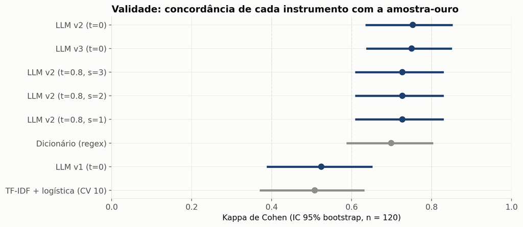

## Como ler a validade

1. **O prompt importa:** v2 (kappa 0,75) supera com folga o v1 sem definições (0,52)
2. **LLM × dicionário:** 0,75 × 0,70, com ICs **sobrepostos**, e o dicionário viu a prova. Com 120 ementas, não há evidência de diferença
3. **O LLM supera o TF-IDF** (0,51), que precisaria de muito mais exemplos
4. As três sementes com t = 0,8 dão **o mesmo** kappa: são idênticas (bloco de confiabilidade)

## Matriz de confusão do melhor LLM

```python
melhor = metricas[metricas.index.str.contains(r"t=0\)")].index[0]
d = aval[aval["instrumento"] == melhor].copy()
conf = pd.crosstab(pd.Categorical(d["categoria"], CATEGORIAS),
                   pd.Categorical(d["categoria_llm"], CATEGORIAS),
                   rownames=["humano"], colnames=["LLM"], dropna=False)
print("Instrumento:", melhor)
conf
```

```
Instrumento: LLM v2 (t=0)
```

| LLM humano | PUNIR | REGULAR | PROMOVER | OUTRO |
| --- | --- | --- | --- | --- |
| PUNIR | 22 | 0 | 0 | 0 |
| REGULAR | 4 | 61 | 4 | 0 |
| PROMOVER | 0 | 2 | 13 | 1 |
| OUTRO | 0 | 5 | 2 | 6 |

- Diagonal: acertos · fora dela: **que** erros o instrumento comete

## Matriz de confusão: a figura

```python
prop = conf.div(conf.sum(axis=1), axis=0)
cmap = plt.matplotlib.colors.LinearSegmentedColormap.from_list("azul", ["#eef4fc", AZUIS[2]])
fig, ax = plt.subplots(figsize=(7.5, 4.8))
ax.imshow(prop.values, cmap=cmap, vmin=0, vmax=1)
for i in range(4):
    for j in range(4):
        ax.text(j, i, conf.values[i, j], ha="center", va="center", fontsize=13,
                color="white" if prop.values[i, j] > .5 else TINTA)
ax.set_xticks(range(4), CATEGORIAS); ax.set_yticks(range(4), CATEGORIAS); ax.grid(False)
ax.set_xlabel("Rótulo do LLM"); ax.set_ylabel("Rótulo humano"); ax.set_title(f"Onde erra: {melhor}")
plt.show()
```

## Matriz de confusão: a figura

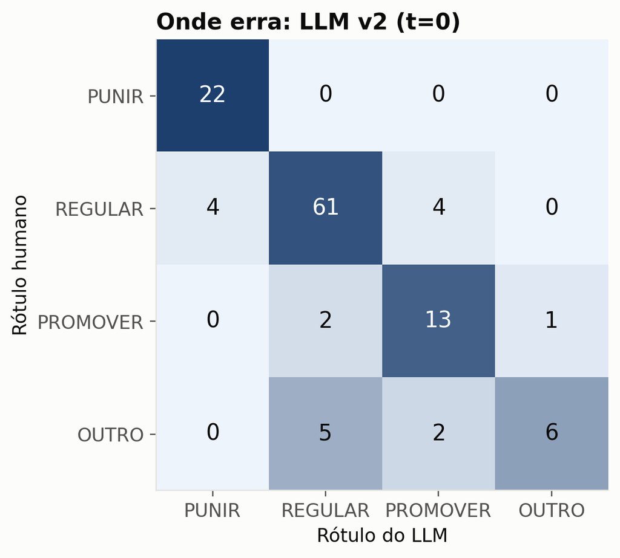

## Nem todo erro é igual

- **REGULAR → PUNIR** infla a proporção punitiva que queremos estimar
- **PUNIR → REGULAR** a reduz
- **REGULAR ↔︎ PROMOVER** não afeta a pergunta sobre punição

```python
erros = d[d["categoria"] != d["categoria_llm"]]
pd.crosstab(erros["categoria"], erros["categoria_llm"], rownames=["humano"], colnames=["LLM"])
```

| LLM humano | OUTRO | PROMOVER | PUNIR | REGULAR |
| --- | --- | --- | --- | --- |
| OUTRO | 0 | 2 | 0 | 5 |
| PROMOVER | 1 | 0 | 0 | 2 |
| REGULAR | 0 | 4 | 4 | 0 |

## Onde estão os erros? Exemplos

```python
ex = erros.merge(corpus[["doc_id", "ementa"]], on="doc_id")
for _, r in ex.head(5).iterrows():
    print(f"{r.doc_id} humano={r.categoria:<8} LLM={r.categoria_llm:<8}\n   {r.ementa[:110]}...")
```

```
doc0013 humano=REGULAR  LLM=PUNIR
   Altera a Lei nº 9.504, de 30 de setembro de 1997, que estabelece normas para as eleições, para dispor sobre a ...
doc0020 humano=REGULAR  LLM=PROMOVER
   Dispõe sobre a criação do Fundo de Renda Básica, que será utilizado para redistribuição de renda para os traba...
doc0034 humano=REGULAR  LLM=PUNIR
   Altera a Lei nº 9.504, de 30 de setembro de 1997, para dispor sobre a vedação à criação, utilização e propagaç...
doc0045 humano=REGULAR  LLM=PUNIR
   Proíbe o uso de Aplicativos e Programas de Inteligência Artificial para criação de “Deep Nudes” e dá outras pr...
doc0073 humano=PROMOVER LLM=REGULAR
   Dispõe sobre a utilização de ferramentas tecnológicas de inteligência artificial para gestão e manutenção de d...
```

**Dica**

Ler os erros é **parte da validação**: às vezes o erro é do modelo; às vezes, do livro de códigos (ou da referência).

## Viés diferencial: a pergunta

> Acurácia alta **na média** não garante comparações válidas **entre grupos**.
- Se o LLM erra mais nas ementas de um campo político, qualquer comparação entre campos feita com seus rótulos estará **enviesada**
- LLMs têm **viés político documentado** (Motoki et al., 2024; Rozado, 2024)
- Medimos: acurácia e proporção PUNIR (humano × LLM) **por campo do autor**

## Viés diferencial: a tabela

```python
dif = d.merge(corpus[["doc_id", "campo"]], on="doc_id").query("campo != 'Sem partido/Outro'")
dif = dif.assign(acerto=dif["categoria"] == dif["categoria_llm"],
                 punir_h=dif["categoria"] == "PUNIR", punir_l=dif["categoria_llm"] == "PUNIR")
vies = dif.groupby("campo").agg(n=("acerto", "size"), acuracia=("acerto", "mean"),
                                prop_punir_humano=("punir_h", "mean"),
                                prop_punir_llm=("punir_l", "mean"))
vies["vies_punir"] = vies["prop_punir_llm"] - vies["prop_punir_humano"]
vies["ep"] = np.sqrt(vies["acuracia"] * (1 - vies["acuracia"]) / vies["n"])
vies["li"], vies["ls"] = vies["acuracia"] - 1.96 * vies["ep"], vies["acuracia"] + 1.96 * vies["ep"]
vies.drop(columns="ep").round(3)
```

| campo | n | acuracia | prop_punir_humano | prop_punir_llm | vies_punir | li | ls |
| --- | --- | --- | --- | --- | --- | --- | --- |
| Centro | 31 | 0.806 | 0.161 | 0.194 | 0.032 | 0.667 | 0.946 |
| Direita | 52 | 0.827 | 0.154 | 0.192 | 0.038 | 0.724 | 0.930 |
| Esquerda | 33 | 0.909 | 0.182 | 0.212 | 0.030 | 0.811 | 1.007 |

## Viés diferencial: a figura

```python
v = vies.sort_values("acuracia")
fig, ax = plt.subplots(figsize=(10, 3.6))
ax.hlines(v.index, v["li"].clip(0), v["ls"].clip(upper=1), color=AZUIS[2], lw=3)
ax.scatter(v["acuracia"], v.index, color=AZUIS[2], s=60, zorder=3)
for campo, r in v.iterrows():
    ax.annotate(f"n = {int(r.n)}", (r.acuracia, campo), xytext=(0, 9),
                textcoords="offset points", ha="center", color=TINTA2, fontsize=9)
ax.set_xlim(0, 1); ax.xaxis.set_major_formatter(pct)
ax.set_title(f"Acurácia por campo político do autor ({melhor}, IC 95%)")
plt.show()
```

## Viés diferencial: a figura

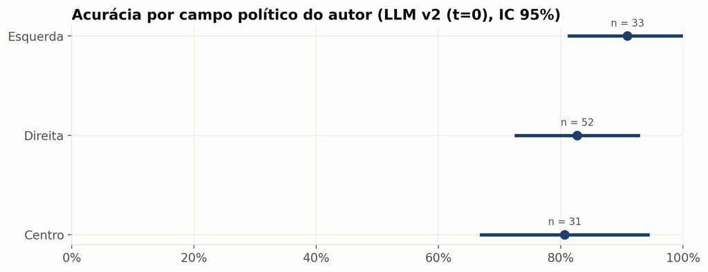

## Teste formal: o acerto depende do campo?

```python
from scipy.stats import chi2_contingency
tab = pd.crosstab(dif["campo"], dif["acerto"])
qui = chi2_contingency(tab)
print(tab, "\n")
print(f"Qui-quadrado = {qui.statistic:.2f}, gl = {qui.dof}, p = {qui.pvalue:.3f}")
```

```
acerto    False  True
campo
Centro        6     25
Direita       9     43
Esquerda      3     30

Qui-quadrado = 1.51, gl = 2, p = 0.469
```

- No R usamos regressão logística (`glm(acerto ~ campo)`), com a mesma conclusão
- **Não rejeitar** ≠ **não há viés**: com 31 a 52 ementas por campo, o teste tem **pouco poder**

**Aviso**

Lição: **com esta amostra-ouro, não é possível descartar viés diferencial**. Isso pesa na inferência por grupo.

## Confiabilidade: o instrumento mede sempre igual?

Duas fontes de instabilidade, **sem precisar de rótulo humano**:

### Teste-reteste

Mesmo prompt (v2), mesma ementa, temperatura 0,8, **três sementes**

### Sensibilidade ao prompt

Mesmo modelo, temperatura 0, **três redações** (v1, v2, v3) do mesmo livro de códigos

**Nota**

Confiabilidade **não é** validade: um instrumento pode ser perfeitamente estável e sistematicamente errado.

## Alfa de Krippendorff

$\alpha = 1 - D_o / D_e$, com $D_o$ = discordância observada e $D_e$ = esperada ao acaso; aceita **k codificadores** e **dados faltantes**.

```python
def alfa_krippendorff(m):                      # m: unidades × codificadores
    m = pd.DataFrame(m)
    valores = sorted({v for v in m.values.ravel() if pd.notna(v)})
    idx = {v: i for i, v in enumerate(valores)}
    o = np.zeros((len(valores), len(valores)))  # matriz de coincidências
    for _, linha in m.iterrows():
        v = [x for x in linha if pd.notna(x)]
        mu = len(v)
        if mu < 2:
            continue
        for i in range(mu):
            for j in range(mu):
                if i != j:
                    o[idx[v[i]], idx[v[j]]] += 1 / (mu - 1)
    nc, n = o.sum(axis=1), o.sum()
    Do = (n - np.trace(o)) / n
    De = (n ** 2 - np.sum(nc ** 2)) / (n * (n - 1))
    return 1 - Do / De
```

## Teste-reteste

```python
largo_seed = (llm[(llm["prompt_id"] == "v2") & (llm["temperatura"] > 0)]
              .pivot(index="doc_id", columns="semente", values="categoria_llm"))
print(largo_seed.head(4), "\n")

def instabilidade(largo):
    """Proporção de ementas com mais de um rótulo entre as execuções."""
    return np.mean([len(set(x.dropna())) > 1 for _, x in largo.iterrows()])

print(f"alfa = {alfa_krippendorff(largo_seed):.3f} · "
      f"ementas que mudam: {instabilidade(largo_seed):.1%}")
```

```
semente        1        2        3
doc_id
doc0001  REGULAR  REGULAR  REGULAR
doc0002  REGULAR  REGULAR  REGULAR
doc0003  REGULAR  REGULAR  REGULAR
doc0004  REGULAR  REGULAR  REGULAR

alfa = 1.000 · ementas que mudam: 0.0%
```

## Sensibilidade ao prompt

```python
largo_prompt = (llm[(llm["temperatura"] == 0) & (llm["semente"] == 42)]
                .pivot(index="doc_id", columns="prompt_id", values="categoria_llm"))
confiab = pd.DataFrame([
    dict(comparacao="Teste-reteste (v2, t=0,8, 3 sementes)",
         alfa=alfa_krippendorff(largo_seed), mudam=instabilidade(largo_seed)),
    dict(comparacao="Sensibilidade ao prompt (v1, v2, v3; t=0)",
         alfa=alfa_krippendorff(largo_prompt), mudam=instabilidade(largo_prompt))])
confiab.round(3)
```

|  | comparacao | alfa | mudam |
| --- | --- | --- | --- |
| 0 | Teste-reteste (v2, t=0,8, 3 sementes) | 1.000 | 0.000 |
| 1 | Sensibilidade ao prompt (v1, v2, v3; t=0) | 0.746 | 0.234 |

**Importante**

**O prompt importa muito mais que o acaso**: trocar a semente não muda nada; trocar a redação muda 23% das ementas.

## Que ementas mudam com o prompt?

```python
muda = largo_prompt[largo_prompt.nunique(axis=1) > 1].merge(
    corpus[["doc_id", "ementa"]], left_index=True, right_on="doc_id")
print(len(muda), "ementas mudam de rótulo entre v1, v2 e v3\n")
for _, r in muda.head(5).iterrows():
    print(f"v1={r.v1:<8} v2={r.v2:<8} v3={r.v3:<8} {r.ementa[:70]}...")
```

```
71 ementas mudam de rótulo entre v1, v2 e v3

v1=OUTRO    v2=REGULAR  v3=OUTRO    Dispõe sobre o uso da Inteligência Artificial....
v1=REGULAR  v2=PROMOVER v3=PROMOVER Dispõe sobre a compatibilização dos sistemas de Inteligência Artificia...
v1=PROMOVER v2=PROMOVER v3=OUTRO    Institui a Política Nacional de Educação Digital; altera as Leis nºs 9...
v1=REGULAR  v2=OUTRO    v3=OUTRO    Dispõe sobre a reforma da Lei nº 9.784/99 (Lei de Processo Administrat...
v1=REGULAR  v2=PROMOVER v3=PROMOVER Estabelece procedimentos a serem adotados pela União em regime de cola...
```

## A medida agregada muda com o prompt

```python
cores_fonte = [AZUIS[0], AZUIS[1], AZUIS[2], CINZA]
fig, axs = plt.subplots(1, 4, figsize=(10, 4), sharey=True, sharex=True)
for ax, c in zip(axs, CATEGORIAS):
    ax.barh(dist.index[::-1], dist[c].values[::-1], color=cores_fonte[::-1], height=.7)
    ax.set_title(c, loc="left", fontsize=10, fontweight="bold")
    ax.set_xticks([0, .3, .6]); ax.set_xlim(0, .65); ax.xaxis.set_major_formatter(pct)
    ax.grid(axis="y", visible=False)
fig.suptitle("Mesmo modelo, mesmos textos, prompts diferentes: medidas diferentes",
             x=.01, ha="left", fontweight="bold")
fig.tight_layout(); plt.show()
```

## A medida agregada muda com o prompt

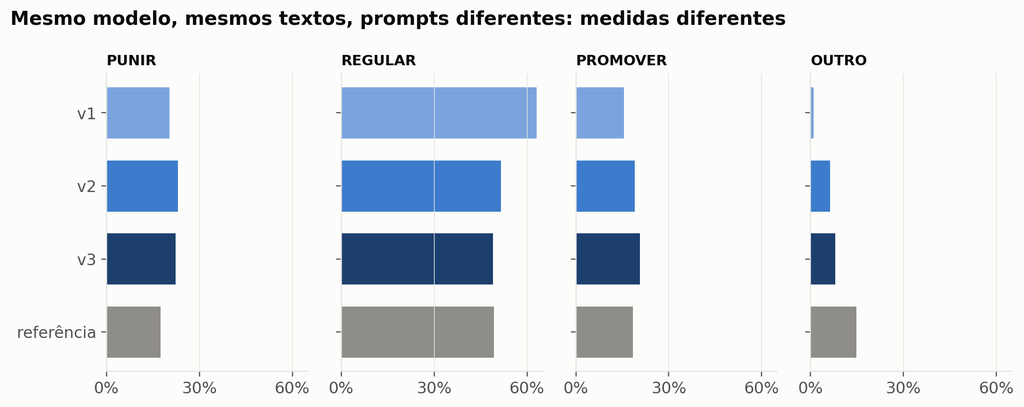

## A variável eleitoral

```python
ele = t0.merge(ouro[["doc_id", "eleitoral"]], on="doc_id")
ele["eleitoral_llm"] = ele["eleitoral_llm"].astype("boolean")
tab_ele = ele.groupby("prompt_id").apply(lambda g: pd.Series(dict(
    n_eleitoral_humano=int(g["eleitoral"].sum()),
    n_eleitoral_llm=int(g["eleitoral_llm"].fillna(False).sum()),
    sensibilidade=g.loc[g["eleitoral"] == 1, "eleitoral_llm"].mean(),
    especificidade=(~g.loc[g["eleitoral"] == 0, "eleitoral_llm"]).mean())))
tab_ele
```

| prompt_id | n_eleitoral_humano | n_eleitoral_llm | sensibilidade | especificidade |
| --- | --- | --- | --- | --- |
| v1 | 8.0 | 8.0 | 1.0 | 1.0 |
| v2 | 8.0 | 8.0 | 1.0 | 1.0 |
| v3 | 8.0 | 8.0 | 1.0 | 1.0 |

- Variável **rara**: acurácia não informa quase nada
- **Sensibilidade**: dos eleitorais, quantos o LLM achou? **Especificidade**: dos não eleitorais, quantos descartou?
- Com só 8 ementas eleitorais na amostra-ouro, a sensibilidade é **muito imprecisa**

## Humano × humano: a comparação que falta

Quando a referência for revisada por **dois codificadores humanos**, este trecho calcula o alfa entre eles:

```python
from pathlib import Path
arqs = sorted(Path("material_apoio/respostas").glob("*.csv"))
if len(arqs) >= 2:
    resp = pd.concat([pd.read_csv(a).assign(codificador=a.stem) for a in arqs])
    resp["categoria"] = resp["categoria"].str.strip().str.upper()
    m = resp.pivot(index="doc_id", columns="codificador", values="categoria")
    print(f"Alfa entre {len(arqs)} codificadores humanos: {alfa_krippendorff(m):.3f}")
else:
    print("Ainda não há respostas suficientes em material_apoio/respostas/ (mínimo: 2).")
```

```
Ainda não há respostas suficientes em material_apoio/respostas/ (mínimo: 2).
```

**A comparação mais honesta**

O LLM concorda com a referência **tanto quanto os humanos concordam entre si**? Neste material a referência é de outra IA, então essa resposta ainda **não existe**.

**Pergunta para a turma**

O kappa do S5-nano contra a referência é alto ou baixo? **Comparado a quê?**

## Síntese da validação

**Importante**

O melhor LLM tem concordância **substancial** com a referência, é **estável** entre sementes, mas é **sensível ao prompt**, e não se pode descartar que erre de forma diferente entre campos políticos.

Ele é um **bom instrumento, mas imperfeito**. O próximo bloco mostra como usá-lo **sem esconder** essa imperfeição.

# 6 · Inferência com rótulos imperfeitos

`python/05_inferencia.ipynb`

## O que vamos executar neste bloco

1. Montar, para cada ementa, o rótulo **humano** $Y$ (só na amostra-ouro) e o do **LLM** $f$
2. Estimar a proporção de projetos **PUNIR** com quatro estimadores
3. Ver o **PPI** passo a passo e o peso $\lambda$ do **PPI++**
4. **Simular** 1.000 amostras-ouro para medir a **cobertura** dos ICs
5. Repetir a análise **por campo político**

## O problema

Queremos $\theta$ = proporção de projetos **PUNIR**. Temos:

- a **amostra-ouro**: $n$ = 120 ementas com rótulo humano $Y_j$ **e** do LLM $f(X_j)$
- as demais $N$ = 184 ementas, **só** com o rótulo do LLM $f(X_i)$

“Humano” = o rótulo de referência. Neste material ele ainda é preliminar e veio de outra IA (bloco 2); o método é o mesmo quando a referência for revisada por humanos.

**Só humanos**
$$\hat\theta_H = \bar Y_n$$
sem viés, mas **impreciso**

**Ingênuo**
$$\hat\theta_{LLM} = \bar f_{N+n}$$
preciso, mas **enviesado**

## Qual instrumento usar?

O de melhor kappa com temperatura 0, entre as execuções que cobrem o corpus inteiro:

```python
llm_of = llm[(llm["temperatura"] > 0) | (llm["semente"] == 42)]   # execuções oficiais
cobre = llm_of[llm_of["temperatura"] == 0].groupby("prompt_id")["doc_id"].nunique()
completos = cobre[cobre == len(corpus)].index.tolist()
av0 = (llm_of[(llm_of["temperatura"] == 0) & llm_of["prompt_id"].isin(completos)]
       .merge(ouro[["doc_id", "categoria"]], on="doc_id"))
kappas = {p: resumo_metricas(g["categoria"], g["categoria_llm"])["kappa"]
          for p, g in av0.groupby("prompt_id")}
PROMPT = max(kappas, key=kappas.get)
print({k: round(v, 3) for k, v in kappas.items()}, "→ prompt escolhido:", PROMPT)
```

```
{'v1': 0.524, 'v2': 0.753, 'v3': 0.75} → prompt escolhido: v2
```

**Aviso**

Escolher pelo kappa **na própria amostra-ouro** é otimista (o mesmo problema do dicionário).

## Montar $Y$ e $f$

```python
dados = (corpus[["doc_id", "ano", "campo", "casa"]]
         .merge(llm_of[(llm_of["prompt_id"] == PROMPT) & (llm_of["temperatura"] == 0)]
                [["doc_id", "categoria_llm"]], on="doc_id", how="left")
         .merge(ref[["doc_id", "categoria"]].rename(columns={"categoria": "categoria_ref"}),
                on="doc_id"))
dados["na_ouro"] = dados["doc_id"].isin(ouro["doc_id"])
dados["f"] = (dados["categoria_llm"] == "PUNIR").astype(int)  # falha de formato = "não PUNIR"
dados["y"] = np.where(dados["na_ouro"], (dados["categoria_ref"] == "PUNIR").astype(int), np.nan)
dados[["doc_id", "campo", "na_ouro", "categoria_llm", "f", "y"]].head(6)
```

|  | doc_id | campo | na_ouro | categoria_llm | f | y |
| --- | --- | --- | --- | --- | --- | --- |
| 0 | doc0001 | Direita | True | REGULAR | 0 | 0.0 |
| 1 | doc0002 | Direita | False | REGULAR | 0 | NaN |
| 2 | doc0003 | Direita | True | REGULAR | 0 | 0.0 |
| 3 | doc0004 | Centro | True | REGULAR | 0 | 0.0 |
| 4 | doc0005 | Esquerda | False | REGULAR | 0 | NaN |
| 5 | doc0006 | Sem partido/Outro | False | REGULAR | 0 | NaN |

## O valor “verdadeiro” (só porque é didático)

```python
verdade = (ref["categoria"] == "PUNIR").mean()
lab, unl = dados[dados["na_ouro"]], dados[~dados["na_ouro"]]
y_n, f_n, f_N = lab["y"].values, lab["f"].values, unl["f"].values
print(f"Proporção PUNIR na referência completa: {verdade:.3f}")
print(f"n = {len(y_n)} rotuladas · N = {len(f_N)} não rotuladas")
print(f"Na amostra-ouro: humano {y_n.mean():.3f} · LLM {f_n.mean():.3f}")
```

```
Proporção PUNIR na referência completa: 0.174
n = 120 rotuladas · N = 184 não rotuladas
Na amostra-ouro: humano 0.183 · LLM 0.217
```

**Nota**

Num estudo real, **não** temos a referência completa. Aqui ela existe para conferirmos quem acerta.

## Só humanos e ingênuo

```python
def ic_normal(est, ep):
    return dict(estimativa=est, ep=ep, li=est - Z * ep, ls=est + Z * ep)

def est_humano(y_n):                  # (a) sem viés, mas com pouca precisão
    y_n = np.asarray(y_n, float)
    return ic_normal(y_n.mean(), y_n.std(ddof=1) / np.sqrt(len(y_n)))

def est_ingenuo(f_todos):             # (b) trata o rótulo do LLM como verdade
    f = np.asarray(f_todos, float)
    return ic_normal(f.mean(), f.std(ddof=1) / np.sqrt(len(f)))
```

```python
fmt = lambda r: f"{r['estimativa']:.3f}  IC [{r['li']:.3f}; {r['ls']:.3f}]  largura {r['ls'] - r['li']:.3f}"
print("Só humanos:", fmt(est_humano(y_n)))
print("Ingênuo:   ", fmt(est_ingenuo(np.concatenate([f_n, f_N]))))
```

```
Só humanos: 0.183  IC [0.114; 0.253]  largura 0.139
Ingênuo:    0.230  IC [0.183; 0.278]  largura 0.095
```

## *Prediction-Powered Inference*

Angelopoulos et al. (2023, *Science*): use a amostra-ouro para **medir o viés do LLM** e subtraí-lo.

$$\hat\theta_{PP} = \underbrace{\frac{1}{N}\sum_{i=1}^{N} f(X_i)}_{\text{LLM no não rotulado}} \; - \; \underbrace{\frac{1}{n}\sum_{j=1}^{n}\big(f(X_j) - Y_j\big)}_{\text{viés medido na amostra-ouro (retificador)}}$$

$$\widehat{\text{Var}}(\hat\theta_{PP}) = \frac{\hat\sigma^2_{f}}{N} + \frac{\hat\sigma^2_{f-Y}}{n}$$

- **Nenhuma hipótese** sobre a qualidade do LLM
- LLM ruim → retificador com variância alta → **IC largo**, nunca **IC errado**

## PPI: o código

```python
def est_ppi(y_n, f_n, f_N):
    """(c) Prediction-Powered Inference (Angelopoulos et al., 2023, Science)."""
    y_n, f_n, f_N = (np.asarray(x, float) for x in (y_n, f_n, f_N))
    ret = f_n - y_n                                   # retificador
    est = f_N.mean() - ret.mean()
    ep = np.sqrt(f_N.var(ddof=1) / len(f_N) + ret.var(ddof=1) / len(y_n))
    return ic_normal(est, ep)
```

São **cinco linhas**. Para pesquisa, confira com o pacote `ppi_py` (Angelopoulos et al.).

## PPI: passo a passo

```python
ret = f_n - y_n
print("Retificador (f - y) na amostra-ouro:", pd.Series(ret).value_counts().sort_index().to_dict())
print("  -1 = LLM disse 'não PUNIR' e o humano 'PUNIR'; +1 = o contrário")
print(f"Média do LLM no não rotulado:    {f_N.mean():.3f}")
print(f"Viés médio do LLM (retificador): {ret.mean():+.3f}")
print(f"PPI = {f_N.mean():.3f} - ({ret.mean():+.3f}) = {f_N.mean() - ret.mean():.3f}")
print(f"EP  = sqrt({f_N.var(ddof=1):.3f}/{len(f_N)} + {ret.var(ddof=1):.3f}/{len(y_n)})"
      f" = {np.sqrt(f_N.var(ddof=1)/len(f_N) + ret.var(ddof=1)/len(y_n)):.4f}")
print("PPI:", fmt(est_ppi(y_n, f_n, f_N)))
```

```
Retificador (f - y) na amostra-ouro: {0.0: 116, 1.0: 4}
  -1 = LLM disse 'não PUNIR' e o humano 'PUNIR'; +1 = o contrário
Média do LLM no não rotulado:    0.239
Viés médio do LLM (retificador): +0.033
PPI = 0.239 - (+0.033) = 0.206
EP  = sqrt(0.183/184 + 0.032/120) = 0.0356
PPI: 0.206  IC [0.136; 0.276]  largura 0.139
```

## PPI++: quanto confiar no LLM?

Pondera o LLM por $\lambda \in [0, 1]$, escolhido para **minimizar a variância** (Angelopoulos, Duchi & Zrnic, 2023): $\hat\theta^{\lambda} = \bar Y_n + \lambda(\bar f_N - \bar f_n)$, com $\hat\lambda = \widehat{\text{Cov}}(Y, f) \,/\, [(1 + n/N)\,\widehat{\text{Var}}(f)]$

```python
def est_ppi_plus(y_n, f_n, f_N):
    y_n, f_n, f_N = (np.asarray(x, float) for x in (y_n, f_n, f_N))
    n, N = len(y_n), len(f_N)
    f_todos = np.concatenate([f_n, f_N])
    lam = np.cov(y_n, f_n, ddof=1)[0, 1] / ((1 + n / N) * f_todos.var(ddof=1))
    lam = float(min(max(lam, 0), 1))
    est = y_n.mean() + lam * (f_N.mean() - f_n.mean())
    ep = np.sqrt((y_n - lam * f_n).var(ddof=1) / n + lam ** 2 * f_N.var(ddof=1) / N)
    return {**ic_normal(est, ep), "lambda": lam}
```

## PPI++: o peso estimado

```python
pp = est_ppi_plus(y_n, f_n, f_N)
print(f"lambda = {pp['lambda']:.3f}")
print("PPI++:", fmt(pp))
```

```
lambda = 0.493
PPI++: 0.194  IC [0.144; 0.245]  largura 0.100
```

- $\lambda \to 0$: o LLM é inútil e o estimador volta a ser o **só humanos**
- $\lambda \to 1$: o LLM é muito bom e o estimador se aproxima do **PPI**
- Aqui, o LLM recebe **cerca de metade** do peso

## Os quatro estimadores lado a lado

```python
est = compara_estimadores(y_n, f_n, f_N).assign(verdade=verdade)
est["largura"] = est["ls"] - est["li"]
est["cobre"] = (est["li"] <= verdade) & (verdade <= est["ls"])
est.set_index("estimador").round(3)
```

| estimador | estimativa | ep | li | ls | lambda | verdade | largura | cobre |
| --- | --- | --- | --- | --- | --- | --- | --- | --- |
| Só humanos (amostra-ouro) | 0.183 | 0.035 | 0.114 | 0.253 | NaN | 0.174 | 0.139 | True |
| Ingênuo (LLM = verdade) | 0.230 | 0.024 | 0.183 | 0.278 | NaN | 0.174 | 0.095 | False |
| PPI | 0.206 | 0.036 | 0.136 | 0.276 | NaN | 0.174 | 0.139 | True |
| PPI++ | 0.194 | 0.026 | 0.144 | 0.245 | 0.493 | 0.174 | 0.100 | True |

## Que proporção dos projetos quer PUNIR?

```python
e = est.iloc[::-1]
fig, ax = plt.subplots(figsize=(10, 3.8))
ax.axvline(verdade, color=CINZA_ESCURO, lw=1.5, ls="--")
ax.text(verdade, 3.35, " valor na referência completa", color=TINTA2, fontsize=9)
ax.hlines(e["estimador"], e["li"], e["ls"], color=e["estimador"].map(COR_EST), lw=3)
ax.scatter(e["estimativa"], e["estimador"], color=e["estimador"].map(COR_EST), s=60, zorder=3)
ax.xaxis.set_major_formatter(pct)
ax.set_title(f"Estimativas com IC 95% · n = {len(y_n)} · N = {len(f_N)}")
plt.show()
```

## Que proporção dos projetos quer PUNIR?

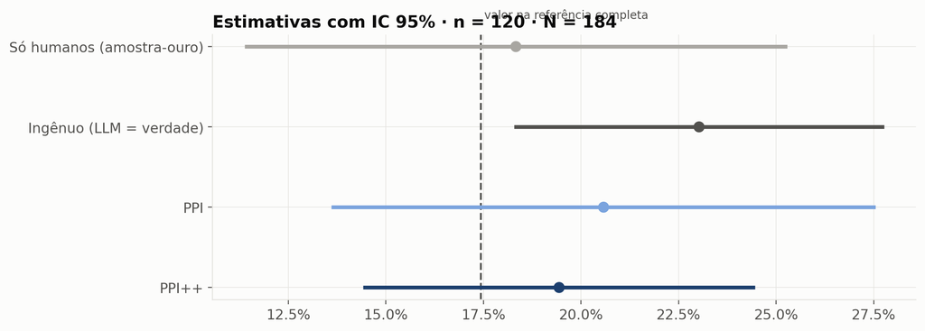

## O que esta amostra mostra

- O **ingênuo** superestima: 23,0% × 17,4% na referência, e seu IC **não contém** a verdade
- **PPI** e **PPI++** corrigem o viés e cobrem a verdade
- O **PPI++** é 28% mais estreito que o “só humanos”

**Nota**

Uma amostra só pode ser sorte. Para avaliar **estimadores**, precisamos repetir o sorteio muitas vezes: **simulação**.

## Simulação: o código

```python
def simula(n_ouro, B=1000, semente=1):
    rng = np.random.default_rng(semente)
    y_todos = (dados["categoria_ref"] == "PUNIR").astype(int).values
    f_todos = dados["f"].values
    res = []
    for _ in range(B):                                    # sorteia uma nova amostra-ouro
        idx = rng.choice(len(dados), n_ouro, replace=False)
        mask = np.zeros(len(dados), bool); mask[idx] = True
        res.append(compara_estimadores(y_todos[mask], f_todos[mask], f_todos[~mask]))
    r = pd.concat(res)
    r["cobre"] = (r["li"] <= verdade) & (verdade <= r["ls"])
    r["largura"] = r["ls"] - r["li"]
    return (r.groupby("estimador", sort=False)
             .agg(cobertura=("cobre", "mean"), largura_media=("largura", "mean"),
                  media=("estimativa", "mean"))
             .assign(vies=lambda x: x["media"] - verdade, n_ouro=n_ouro)
             .drop(columns="media").reset_index())
```

## Simulação: resultados

```python
sim = pd.concat([simula(n) for n in (30, 60, 120)], ignore_index=True)
sim.pivot(index="estimador", columns="n_ouro", values=["cobertura", "largura_media"]).round(3)
```

| n_ouro estimador | cobertura 30 | cobertura 60 | cobertura 120 | largura_media 30 | largura_media 60 | largura_media 120 |
| --- | --- | --- | --- | --- | --- | --- |
| Ingênuo (LLM = verdade) | 0.000 | 0.000 | 0.000 | 0.095 | 0.095 | 0.095 |
| PPI | 0.846 | 0.974 | 0.988 | 0.188 | 0.157 | 0.147 |
| PPI++ | 0.869 | 0.970 | 1.000 | 0.160 | 0.125 | 0.103 |
| Só humanos (amostra-ouro) | 0.897 | 0.971 | 0.989 | 0.267 | 0.192 | 0.136 |

- 3 tamanhos × 1.000 sorteios × 4 estimadores = **12.000 intervalos**
- Um bom IC de 95% deve conter a verdade em **~95%** das vezes

## Com que frequência o IC acerta?

```python
fig, ax = plt.subplots(figsize=(10, 4.5))
for nome, dd in sim.groupby("estimador", sort=False):
    ax.plot(dd["n_ouro"].astype(str), dd["cobertura"], "o-", color=COR_EST[nome], lw=2, label=nome)
ax.axhline(.95, color=TINTA2, ls="--"); ax.set_ylim(0, 1.02); ax.yaxis.set_major_formatter(pct)
ax.set_title("Cobertura do IC de 95% em 1.000 sorteios da amostra-ouro")
ax.set_xlabel("Tamanho da amostra-ouro"); ax.legend(frameon=False, fontsize=9, loc="center right")
plt.show()
```

## Com que frequência o IC acerta?

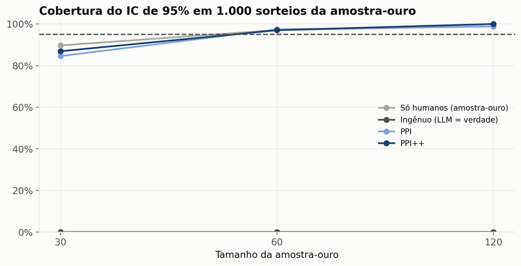

## O preço da honestidade

```python
fig, ax = plt.subplots(figsize=(10, 4.5))
for nome, dd in sim.groupby("estimador", sort=False):
    ax.plot(dd["n_ouro"].astype(str), dd["largura_media"], "o-", color=COR_EST[nome], lw=2, label=nome)
ax.yaxis.set_major_formatter(pct); ax.set_xlabel("Tamanho da amostra-ouro")
ax.set_title("Largura média do IC: o ingênuo é estreito porque ignora o erro do LLM")
ax.legend(frameon=False, fontsize=9)
plt.show()
```

## O preço da honestidade

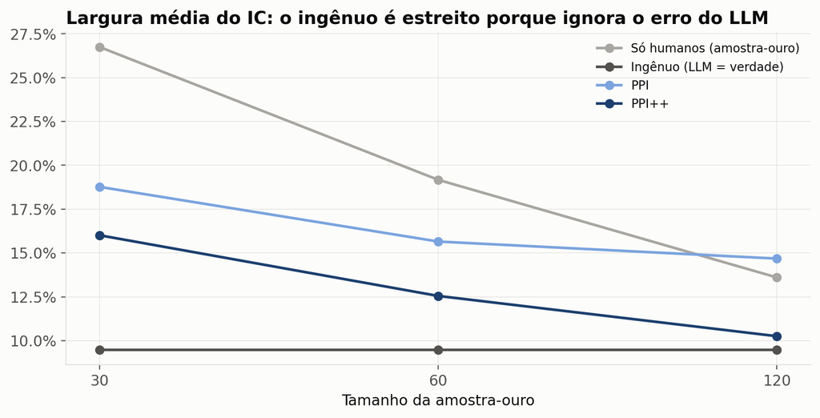

## Lendo a simulação

- O IC **ingênuo** cobriu a verdade em **0%** das simulações, para qualquer $n$: é estreito porque **ignora** o erro
- O **PPI++** com $n$ = 120 cobre 100,0%, com largura média de 10,3% (só humanos: 13,6%)
- Com $n$ = 30, todos os honestos ficam **abaixo de 95%**: amostras-ouro muito pequenas comprometem a aproximação normal
- O viés do ingênuo é **sistemático** (+5,6 p.p.); o dos outros, **acaso**

## E entre campos políticos?

```python
linhas = []
for campo, dd in dados[dados["campo"].isin(["Esquerda", "Centro", "Direita"])].groupby("campo"):
    l, u = dd[dd["na_ouro"]], dd[~dd["na_ouro"]]
    linhas.append(compara_estimadores(l["y"].values, l["f"].values, u["f"].values)
                  .assign(campo=campo, n_ouro=len(l),
                          verdade=(dd["categoria_ref"] == "PUNIR").mean()))
por_campo = pd.concat(linhas, ignore_index=True)
por_campo.pivot(index="estimador", columns="campo", values="estimativa").round(3)
```

| campo estimador | Centro | Direita | Esquerda |
| --- | --- | --- | --- |
| Ingênuo (LLM = verdade) | 0.230 | 0.219 | 0.225 |
| PPI | 0.234 | 0.195 | 0.204 |
| PPI++ | 0.188 | 0.174 | 0.193 |
| Só humanos (amostra-ouro) | 0.161 | 0.154 | 0.182 |

```python
por_campo.groupby("campo")[["n_ouro", "verdade"]].first().round(3).T
```

| campo | Centro | Direita | Esquerda |
| --- | --- | --- | --- |
| n_ouro | 31.000 | 52.000 | 33.000 |
| verdade | 0.131 | 0.174 | 0.188 |

## Por campo: a figura

```python
ests = ["Só humanos (amostra-ouro)", "Ingênuo (LLM = verdade)", "PPI", "PPI++"]
fig, axs = plt.subplots(1, 3, figsize=(10, 4.6), sharey=True, sharex=True)
for ax, campo in zip(axs, ["Esquerda", "Centro", "Direita"]):
    dd = por_campo[por_campo["campo"] == campo].set_index("estimador").loc[ests[::-1]]
    ax.axvline(dd["verdade"].iloc[0], color=CINZA_ESCURO, lw=1.2, ls="--")
    ax.hlines(dd.index, dd["li"].clip(0), dd["ls"], color=[COR_EST[i] for i in dd.index], lw=3)
    ax.scatter(dd["estimativa"], dd.index, color=[COR_EST[i] for i in dd.index], s=50, zorder=3)
    ax.set_title(f"{campo} (n = {dd['n_ouro'].iloc[0]})", fontsize=11)
    ax.xaxis.set_major_formatter(pct)
fig.suptitle("Proporção PUNIR por campo do autor (tracejado: referência)", x=.01, ha="left",
             fontweight="bold"); fig.tight_layout(); plt.show()
```

## Por campo: a figura

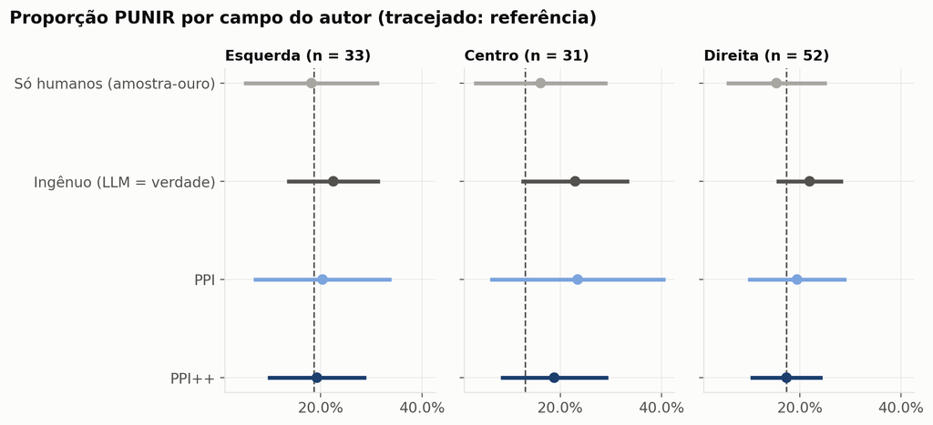

## Por campo: o que concluir

- Por campo, a amostra-ouro tem só **31 a 52** ementas: ICs **largos**
- Os estimadores discordam sobre a **ordem** dos campos, e todos os ICs se sobrepõem
- **Não há evidência**, com estes dados, de que um campo legisle de forma mais punitiva

**Importante**

Em análises por subgrupo, relatar o **tamanho da amostra-ouro em cada grupo** é obrigatório.

## O que os números dizem

- **O prompt importa mais que o acaso:** trocar a semente muda 0% dos rótulos; trocar o prompt muda 23%
- **O ingênuo engana:** superestima a proporção punitiva e seu IC **nunca** cobriu a verdade na simulação
- **O PPI++ corrige o viés** e entrega um IC mais estreito que o “só humanos”
- **Resposta substantiva (ilustrativa):** cerca de **19%** dos projetos sobre IA querem **punir** (PPI++, IC 14%–24%); na referência, cerca de metade **regula** (49%)

## Resumo do bloco 6

**O que fizemos**

- Tratar o LLM como verdade dá um IC **estreito e errado**
- **PPI** usa a amostra-ouro para medir e subtrair o viés do LLM: IC honesto
- **PPI++** decide pelos dados quanto confiar no LLM ($\lambda$)
- A **simulação** é a forma de avaliar estimadores, não uma amostra só

Abordagens relacionadas: *Design-based Supervised Learning* (Egami et al., 2023) para regressões.

# 7 · Reprodutibilidade (MLOps)

`python/anotar_llm.py` · `_targets.R` · `CHECKLIST.md`

## O que vamos executar neste bloco

1. Listar **o que precisa ser versionado** numa pesquisa com LLM
2. Ver como o pipeline é refeito (Python: notebooks e linha de comando; R: `targets`)
3. Medir o *drift* do próprio instrumento: repetir a anotação a t = 0
4. Registrar o **ambiente** (versões dos pacotes)
5. Discutir **código gerado por IA**

## O que precisa ser versionado?

| Componente | Como versionar | Neste material |
| --- | --- | --- |
| **Código** | Git | `python/`, `R/` |
| **Ambiente** | `requirements.txt` / `renv` / Docker | `requirements.txt` |
| **Dados brutos** | congelados, com data | `dados/bruto/`, `corpus.csv` |
| **Instrumento** | pesos (digest) + prompt (hash) + parâmetros | `modelos/`, `prompts/`, cada registro |
| **Respostas do LLM** | cache (é dado, não lixo) | `dados/cache_llm/*.jsonl` |
| **Referência humana** | codificador + status de revisão | `referencia_completa.csv` |

## Refazendo tudo em Python

```bash
# 1. ambiente
pip install -r requirements.txt

# 2. (opcional) coleta nova: abre 01_coleta.ipynb com MODO_TESTE = False  (~5–10 min)

# 3. (opcional) anotação: retoma de onde parou, não refaz o que está no cache
python python/anotar_llm.py --todas            # plano completo: 6 execuções
python python/anotar_llm.py --prompt v2 --temperatura 0 --semente 42 --n 10   # teste

# 4. análises a partir dos dados e do cache congelados
jupyter nbconvert --to notebook --execute --inplace python/02_baselines.ipynb \
    python/04_validacao.ipynb python/05_inferencia.ipynb
```

As tabelas e figuras vão para `resultados/python/`; as do R, para `resultados/`.

## Em R: um pipeline declarativo (`targets`)

```r
tar_target(arq_prompts, list.files("prompts", "\\.txt$", full.names = TRUE),
           format = "file", cue = tar_cue(mode = "always")),
tar_target(arq_cache_llm, list.files("dados/cache_llm", "\\.jsonl$", full.names = TRUE),
           format = "file", cue = tar_cue(mode = "always")),
tar_target(validacao,
  roda_script("R/05_validacao.R", saidas, baselines, arq_cache_llm, arq_prompts, ...),
  format = "file")
```

```r
targets::tar_make()        # roda só o que mudou
targets::tar_outdated()    # editei o prompt v2... o que ficou desatualizado?
targets::tar_visnetwork()  # desenha o grafo de dependências
```

## Uma armadilha do próprio pipeline

**Encontrada na verificação deste material**

Com só `format = "file"`, o `targets` detectava **edições** em arquivos conhecidos, mas **não arquivos novos**: um prompt v4 ou uma nova execução do LLM passariam despercebidos, e as tabelas ficariam velhas **em silêncio**.

- Correção: `cue = tar_cue(mode = "always")` nas entradas que listam arquivos
- Lição: **ferramentas de reprodutibilidade também precisam ser testadas**

## *Drift*: quando o instrumento muda sozinho

- API comercial atualiza o modelo → **mesmo prompt, outra medida**
- Defesa: modelo **local com versão fixa**, ou registrar `model_id` + data + respostas brutas
- Monitorar: **re-anotar a amostra-ouro** periodicamente e acompanhar o kappa

**E com modelo local, t = 0, mesmos pesos?** Em 12/11/2026 repetimos as três anotações a temperatura 0:

```bash
python python/anotar_llm.py --todas-t0 --pasta dados/repeticao
```

## Repetição a t = 0: o mesmo instrumento?

```python
linhas, mud = [], []
for p in ["v1", "v2", "v3"]:
    arq = f"s5-nano-instruct__{p}__t0.0__s42.jsonl"
    a = pd.read_json(f"dados/cache_llm/{arq}", lines=True)
    b = pd.read_json(f"dados/repeticao/{arq}", lines=True)
    mm = a.merge(b, on="doc_id", suffixes=("_1", "_2"))
    linhas.append(dict(prompt=p, n=len(mm),
                       mesmo_digest=(mm.modelo_digest_1 == mm.modelo_digest_2).all(),
                       mesmo_ollama=(mm.ollama_versao_1 == mm.ollama_versao_2).all(),
                       mesmo_prompt=(mm.prompt_sha_1 == mm.prompt_sha_2).all(),
                       mudaram=int((mm.categoria_llm_1 != mm.categoria_llm_2).sum())))
    mud.append(mm.loc[mm.categoria_llm_1 != mm.categoria_llm_2,
                      ["doc_id", "prompt_id_1", "categoria_llm_1", "categoria_llm_2"]])
repet = pd.DataFrame(linhas)
repet
```

|  | prompt | n | mesmo_digest | mesmo_ollama | mesmo_prompt | mudaram |
| --- | --- | --- | --- | --- | --- | --- |
| 0 | v1 | 304 | True | True | True | 0 |
| 1 | v2 | 304 | True | True | True | 3 |
| 2 | v3 | 304 | True | True | True | 2 |

## Quais ementas mudaram?

```python
(pd.concat(mud).merge(corpus[["doc_id", "ementa"]], on="doc_id")
   .rename(columns={"prompt_id_1": "prompt", "categoria_llm_1": "1ª execução",
                    "categoria_llm_2": "repetição"})
   .assign(ementa=lambda x: x["ementa"].str[:60] + "..."))
```

|  | doc_id | prompt | 1ª execução | repetição | ementa |
| --- | --- | --- | --- | --- | --- |
| 0 | doc0059 | v2 | REGULAR | PUNIR | Institui campanha de prevenção e combate aos crimes digitais... |
| 1 | doc0233 | v2 | PUNIR | REGULAR | Dispõe sobre medidas de prevenção, combate e responsabilizaç... |
| 2 | doc0255 | v2 | OUTRO | PROMOVER | Institui o Programa Nacional de Municípios Inteligentes e Su... |
| 3 | doc0267 | v3 | PROMOVER | REGULAR | Altera a Lei nº 12.651, de 25 de maio de 2012 (Código Flores... |
| 4 | doc0272 | v3 | PUNIR | REGULAR | Altera a Lei nº 13.105, de 16 de março de 2015, para caracte... |

## Temperatura 0 não garante a mesma resposta

- 5 de 912 rótulos mudaram, **com os mesmos pesos, Ollama, prompt e semente**
- Causa: pequenas diferenças numéricas na **GPU**; quando duas respostas estão quase empatadas, isso basta para trocar a mais provável
- Uma delas (doc0233) já estava entre os casos **ambíguos** do livro de códigos

**Importante**

A replicação **exata** vem do **cache** das respostas brutas, não de reexecutar o modelo. E o instrumento inclui o **software** que roda o modelo.

## O ambiente também é parte do resultado

```python
import platform, sklearn, matplotlib, scipy
print("Python     ", platform.python_version(), "·", platform.system())
for mod in (np, pd, sklearn, scipy, matplotlib, requests):
    print(f"{mod.__name__:<11}", mod.__version__)
print("\nrequirements.txt:")
print(open("requirements.txt", encoding="utf-8").read())
```

```
Python      3.11.5 · Linux
numpy       1.26.4
pandas      2.1.4
sklearn     1.4.2
scipy       1.11.4
matplotlib  3.7.5
requests    2.32.3

requirements.txt:
# Trilha Python do minicurso (testado com Python 3.11)
pandas>=2.0
numpy>=1.24
requests>=2.31
scikit-learn>=1.3
matplotlib>=3.7
jupyter
# opcional (API comercial):
# openai>=1.40
```

## Código gerado por IA

- **Agentes de programação** (Claude Code, Codex…) também produzem análises, cada vez mais
- Regra proposta: **trate o código gerado por IA como o de um coautor**
  - revisão, testes, versionamento
  - quem publica **responde** por ele
- Este material foi produzido com auxílio do Claude Opus 5.5, e o uso está **declarado** no livro
- A verificação encontrou e corrigiu falhas reais (a armadilha do `targets`, caches de outro modelo misturados)

## Checklist para o seu próximo artigo

**Antes de anotar**

- Livro de códigos testado com humanos
- Amostra-ouro **aleatória**
- Baseline barato para comparar

**Durante**

- Modelo, digest, software, prompt (hash), parâmetros
- Respostas **brutas** guardadas
- Falhas de formato **contadas**

**Validação**

- Kappa **com IC**, matriz de confusão
- Viés diferencial entre grupos
- Teste-reteste e sensibilidade ao prompt

**Inferência e replicação**

- Corrigir o erro (PPI, DSL)
- Ambiente, dados e cache congelados

Completo em `CHECKLIST.md`.

## Resumo do bloco 7

**O que fizemos**

- Versionar **código, ambiente, dados, instrumento e respostas**
- Mesmo um modelo **local** com t = 0 muda alguns rótulos: o **cache** é a replicação
- Ferramentas de reprodutibilidade também falham e precisam ser **testadas**

# 8 · Ética, limites e debate

`material_apoio/contexto_regulatorio.md`

## IA na política brasileira em 2026

### Eleições (TSE)

- Res. 23.755/2026: **rotulagem** de conteúdo sintético
- **Deepfakes** proibidos, mesmo com autorização
- Vedação de novos conteúdos sintéticos **72h antes / 24h depois** da votação
- IA não pode **recomendar voto**

### Congresso

- **PL 2338/2023**: risco, direitos, SIA, sanções de até R$ 50 mi
- Na Câmara desde mar/2025; **aguardando parecer**
- Enquanto isso: 294 projetos desde 2023, muitos **punitivos** e **fragmentados**

## Para debater

1. Se um LLM classifica 304 ementas em poucos minutos, ainda precisamos de codificadores humanos? **Para quê, exatamente?**
2. Modelo **local** (reprodutível) com kappa menor × API **comercial** com kappa maior?
3. O **viés político** dos LLMs (Motoki et al., 2024) pode contaminar comparações entre campos? Como testar?
4. Rotulagem obrigatória de conteúdo sintético é **verificável**? Quem audita o detector?

## Quando **não** usar um LLM

- O conceito não tem **definição operacional** clara
- Não há como montar uma **amostra-ouro**
- O erro do modelo é **correlacionado** com a variável explicativa e não pode ser corrigido
- Poucos documentos: codificar à mão é mais barato e mais confiável
- Os dados não podem sair da instituição e não há modelo local adequado

## Mensagem final

**Importante**

A IA amplia as formas de responder,  
mas **não substitui** a boa pergunta, o desenho de pesquisa e a **validação estatística**.

- **Material completo:** repositório do minicurso (Python + R + dados + cache do LLM)
- **Notebooks para o Colab:** `python/01…05_*.ipynb`
- **Checklist** para o seu próximo artigo: `CHECKLIST.md`

**Jodavid Ferreira** · jodavid.ferreira@ufpe.br · jodavid.github.io

## Referências

- Angelopoulos, A. N. et al. (2023). Prediction-powered inference. *Science*, 382(6671).
- Angelopoulos, A. N.; Duchi, J.; Zrnic, T. (2023). PPI++: Efficient prediction-powered inference. *arXiv:2311.01453*.
- Bolognesi, B.; Ribeiro, E.; Codato, A. (2023). A new ideological classification of Brazilian political parties. *Dados*, 66(2).
- Breiman, L. (2001). Statistical modeling: the two cultures. *Statistical Science*, 16(3).
- Chernozhukov, V. et al. (2018). Double/debiased machine learning. *The Econometrics Journal*, 21(1).
- Egami, N. et al. (2023). Using imperfect surrogates for downstream inference. *NeurIPS*.
- Gilardi, F.; Alizadeh, M.; Kubli, M. (2023). ChatGPT outperforms crowd workers for text-annotation tasks. *PNAS*, 120(30).
- Grimmer, J.; Roberts, M.; Stewart, B. (2022). *Text as Data*. Princeton University Press.
- Krippendorff, K. (2018). *Content Analysis* (4ª ed.). SAGE.
- Landis, J. R.; Koch, G. G. (1977). The measurement of observer agreement for categorical data. *Biometrics*, 33(1).
- Motoki, F.; Pinho Neto, V.; Rodrigues, V. (2024). More human than human: measuring ChatGPT political bias. *Public Choice*, 198.
- Pedregosa, F. et al. (2011). Scikit-learn: Machine learning in Python. *JMLR*, 12.
- Tribunal Superior Eleitoral. Resolução nº 23.755, de 2 de março de 2026.
- Vovk, V.; Gammerman, A.; Shafer, G. (2005). *Algorithmic Learning in a Random World*. Springer.